# Richter's Predictor: Modeling Earthquake Damage

### Predicting Earthquake Building Damage Grades

## Problem Statement

On **25 April 2015**, a magnitude-7.8 earthquake struck Nepal. In its aftermath, Kathmandu Living Labs and the Central Bureau of Statistics (under Nepal's National Planning Commission) surveyed hundreds of thousands of buildings to record the damage each one sustained. Manually assessing every building at this scale is far too slow, so the goal of this project is to **predict a building's damage grade automatically** from its structural, geographic, and ownership characteristics.

The target, `damage_grade`, is an **ordinal** variable with three levels:

| Grade | Meaning |
| --- | --- |
| **1** | Low damage |
| **2** | Medium damage |
| **3** | Near-total destruction |

This is a **multi-class (ordinal) classification** problem built on one of the largest post-disaster survey datasets ever collected. It mixes heavily categorical structural features (foundation type, roof material, land surface condition, legal ownership) with hierarchical geo-location IDs and normalized numeric features, more real-world messiness than a typical tabular-ML dataset.

**Dataset at a glance**

|  | Rows | Columns |
| --- | --- | --- |
| `train_values` + `train_labels` | 260,601 | 39 |
| `test_values` | 86,868 | 39 |
| **Combined** | **347,469** | 75% / 25% train-test split |

## Feature Description

Each building is described by **38 features** (plus the `building_id` identifier), grouped as follows:

| Group | Count | Examples |
| --- | --- | --- |
| Geographic (hierarchical) | 3 | `geo_level_1_id` (0-30) -> `geo_level_2_id` (0-1427) -> `geo_level_3_id` (0-12567) |
| Numeric building characteristics | 5 | `count_floors_pre_eq`, `age`, `area_percentage`, `height_percentage`, `count_families` |
| Categorical building characteristics | 8 | `land_surface_condition`, `foundation_type`, `roof_type`, `ground_floor_type`, `other_floor_type`, `position`, `plan_configuration`, `legal_ownership_status` |
| Superstructure material flags (binary) | 11 | `has_superstructure_mud_mortar_stone`, `has_superstructure_timber`, `has_superstructure_rc_engineered`, ... |
| Secondary-use flags (binary) | 11 | `has_secondary_use` (umbrella) plus 10 sub-flags: `_agriculture`, `_hotel`, `_rental`, `_institution`, `_school`, `_industry`, `_health_post`, `_gov_office`, `_use_police`, `_other` |

The geo-location IDs form a **strict three-level hierarchy** (every `geo_level_3_id` nests inside exactly one `geo_level_2_id`, which nests inside exactly one `geo_level_1_id`), which is why they're target/frequency encoded rather than one-hot encoded. The 8 categorical columns are all low-cardinality (3-10 levels) and are one-hot encoded instead.

## Project Roadmap

#### A. Exploratory Data Analysis

1. Load the training features, training labels, and test features.
2. Confirm ID integrity: unique identifiers within each set, no overlap between train and test, and row-alignment between features and labels.
3. Inspect shape, columns, and dtypes.
4. Check missing values.
5. Check duplicate rows (full duplicates and feature-level duplicates).
6. Check invalid / sentinel values.
7. Analyse distributions of individual features.
8. Analyse the target variable: class balance / shape, and its implications for metric choice and cross-validation strategy.
9. Check cardinality and structure of any hierarchical or high-cardinality features -- this will decide encoding strategy later.
10. Check relationships / correlations between features and the target.
11. Summarise data-quality findings and their modeling implications.

#### B. Cleaning

12. Define deterministic cleaning rules from the EDA findings, separating row-dropping rules from capping/clipping rules.
13. Apply row-dropping rules to train only -- the test set has no label to justify a drop, and every test row must still receive a prediction.
14. Apply capping/clipping rules identically to train and test, using bounds derived from train only.

#### C. Preprocessing

15. Split features (X) and target (y) from the cleaned training set.
16. Build a preprocessing pipeline (encoders/scalers appropriate to each feature type).
17. Fit simple transformers on the training features only; if any encoder uses target information, fit it out-of-fold to avoid leakage.
18. Transform the training features.
19. Transform the held-out validation split and the test features using the transformer(s) fit on train only.

#### D. Model

20. Establish a naive baseline to contextualize later scores.
21. Train candidate models and compare via cross-validation on the competition metric.
22. Tune hyperparameters of the best candidate.
23. Refit the final model on the full cleaned training set.
24. Evaluate on a held-out split to check for systematic error patterns.
25. Predict on the test set, format the submission, and sanity-check the predicted distribution against train.

## 1. Exploratory Data Analysis

This section explores the dataset in depth before any modelling takes place, moving through four phases: understanding the raw data, checking it for quality issues, exploring feature-target relationships, and summarising the findings.

### 1.1 Understand

This section establishes what the raw data looks like: its structure, feature groups, and how the modelling matrix is assembled.

First step is to load the required libraries and load the data (**The libraries has been appended after each stage**).

```python
import os
from pathlib import Path

import numpy as np
import pandas as pd
import matplotlib.pyplot as plt
import matplotlib.ticker as mticker
import seaborn as sns
from scipy.stats import chi2_contingency

from sklearn.base import BaseEstimator, TransformerMixin
from sklearn.compose import ColumnTransformer
from sklearn.model_selection import StratifiedKFold
from sklearn.pipeline import Pipeline
from sklearn.preprocessing import OneHotEncoder, MinMaxScaler
from sklearn.utils.validation import check_is_fitted

pd.set_option("display.max_columns", None)
pd.set_option("display.width", 200)
pd.set_option("display.max_rows", 100)

print("Libraries all loaded to goooo!!!")
```

```
Libraries all loaded to goooo!!!
```

```python
from pathlib import Path

import pandas as pd


DATA_DIR = Path("../datasets")

TRAIN_VALUES_FILE = DATA_DIR / "train_values.csv"
TRAIN_LABELS_FILE = DATA_DIR / "train_labels.csv"
TEST_VALUES_FILE = DATA_DIR / "test_values.csv"


def load_data(data_dir: Path):
    """Load train_values, train_labels, and test_values from data_dir."""

    files = {
        "train_values": data_dir / "train_values.csv",
        "train_labels": data_dir / "train_labels.csv",
        "test_values": data_dir / "test_values.csv",
    }

    missing = [str(p) for p in files.values() if not p.exists()]

    if missing:
        raise FileNotFoundError(
            f"Expected data file(s) not found: {missing}. "
            f"Pass the correct folder with --data-dir."
        )

    train_values = pd.read_csv(files["train_values"])
    train_labels = pd.read_csv(files["train_labels"])
    test_values = pd.read_csv(files["test_values"])

    return train_values, train_labels, test_values


train_values, train_labels, test_values = load_data(DATA_DIR)

print("Data loaded successfully!")
```

```
Data loaded successfully!
```

#### 1.1.1 Initial Dataset Inspection

Before modelling, we verify the structure of the three datasets and confirm that the training features and labels align correctly.

```python
print("Train values shape :", train_values.shape)
print("Train labels shape :", train_labels.shape)
print("Test values shape  :", test_values.shape)
```

```
Train values shape : (260601, 39)
Train labels shape : (260601, 2)
Test values shape  : (86868, 39)
```

```python
ID_COL = "building_id"
TARGET_COL = "damage_grade"

assert ID_COL in train_values.columns
assert ID_COL in train_labels.columns
assert ID_COL in test_values.columns
assert TARGET_COL in train_labels.columns

assert len(train_values) == len(train_labels)
assert train_values[ID_COL].equals(train_labels[ID_COL])

print("Training features and labels are correctly aligned.")
```

```
Training features and labels are correctly aligned.
```

#### 1.1.2 Feature Groups

The dataset contains several types of variables:

- Geographic identifiers
- Continuous/count variables
- Categorical building characteristics
- Binary structural-material indicators
- Binary secondary-use indicators

The geographic IDs are treated as categorical variables by LightGBM because their numeric values represent geographic identifiers rather than continuous measurements.

```python
RANDOM_STATE = 42

GEO_COLS = [
    "geo_level_1_id",
    "geo_level_2_id",
    "geo_level_3_id",
]

NUMERIC_COLS = [
    "count_floors_pre_eq",
    "age",
    "area_percentage",
    "height_percentage",
    "count_families",
]

CATEGORICAL_COLS = [
    "land_surface_condition",
    "foundation_type",
    "roof_type",
    "ground_floor_type",
    "other_floor_type",
    "position",
    "plan_configuration",
    "legal_ownership_status",
]

SUPERSTRUCTURE_COLS = [
    "has_superstructure_adobe_mud",
    "has_superstructure_mud_mortar_stone",
    "has_superstructure_stone_flag",
    "has_superstructure_cement_mortar_stone",
    "has_superstructure_mud_mortar_brick",
    "has_superstructure_cement_mortar_brick",
    "has_superstructure_timber",
    "has_superstructure_bamboo",
    "has_superstructure_rc_non_engineered",
    "has_superstructure_rc_engineered",
    "has_superstructure_other",
]

SECONDARY_USE_UMBRELLA_COL = "has_secondary_use"

SECONDARY_USE_SUB_COLS = [
    "has_secondary_use_agriculture",
    "has_secondary_use_hotel",
    "has_secondary_use_rental",
    "has_secondary_use_institution",
    "has_secondary_use_school",
    "has_secondary_use_industry",
    "has_secondary_use_health_post",
    "has_secondary_use_gov_office",
    "has_secondary_use_use_police",
    "has_secondary_use_other",
]

SECONDARY_USE_COLS = [
    SECONDARY_USE_UMBRELLA_COL,
    *SECONDARY_USE_SUB_COLS,
]

BINARY_COLS = [
    *SUPERSTRUCTURE_COLS,
    *SECONDARY_USE_COLS,
]

ALL_FEATURE_COLS = [
    *GEO_COLS,
    *NUMERIC_COLS,
    *CATEGORICAL_COLS,
    *BINARY_COLS,
]

print(f"Total model features: {len(ALL_FEATURE_COLS)}")

assert len(ALL_FEATURE_COLS) == 38
assert set(ALL_FEATURE_COLS) == (
    set(train_values.columns) - {ID_COL}
)

print("Feature definitions verified.")
```

```
Total model features: 38
Feature definitions verified.
```

#### 1.1.3 Modelling Data

`building_id` is an identifier and is not used as a predictive feature.

The target is kept separately from the feature matrix.

```python
X = train_values.drop(columns=[ID_COL]).copy()
y = train_labels[TARGET_COL].copy()

X_test = test_values.drop(columns=[ID_COL]).copy()

print("X shape      :", X.shape)
print("y shape      :", y.shape)
print("X_test shape:", X_test.shape)
```

```
X shape      : (260601, 38)
y shape      : (260601,)
X_test shape: (86868, 38)
```

```python
X.head()
```

|  | geo_level_1_id | geo_level_2_id | geo_level_3_id | count_floors_pre_eq | age | area_percentage | height_percentage | land_surface_condition | foundation_type | roof_type | ground_floor_type | other_floor_type | position | plan_configuration | has_superstructure_adobe_mud | has_superstructure_mud_mortar_stone | has_superstructure_stone_flag | has_superstructure_cement_mortar_stone | has_superstructure_mud_mortar_brick | has_superstructure_cement_mortar_brick | has_superstructure_timber | has_superstructure_bamboo | has_superstructure_rc_non_engineered | has_superstructure_rc_engineered | has_superstructure_other | legal_ownership_status | count_families | has_secondary_use | has_secondary_use_agriculture | … |
| --- | --- | --- | --- | --- | --- | --- | --- | --- | --- | --- | --- | --- | --- | --- | --- | --- | --- | --- | --- | --- | --- | --- | --- | --- | --- | --- | --- | --- | --- | --- |
| 0 | 6 | 487 | 12198 | 2 | 30 | 6 | 5 | t | r | n | f | q | t | d | 1 | 1 | 0 | 0 | 0 | 0 | 0 | 0 | 0 | 0 | 0 | v | 1 | 0 | 0 | … |
| 1 | 8 | 900 | 2812 | 2 | 10 | 8 | 7 | o | r | n | x | q | s | d | 0 | 1 | 0 | 0 | 0 | 0 | 0 | 0 | 0 | 0 | 0 | v | 1 | 0 | 0 | … |
| 2 | 21 | 363 | 8973 | 2 | 10 | 5 | 5 | t | r | n | f | x | t | d | 0 | 1 | 0 | 0 | 0 | 0 | 0 | 0 | 0 | 0 | 0 | v | 1 | 0 | 0 | … |
| 3 | 22 | 418 | 10694 | 2 | 10 | 6 | 5 | t | r | n | f | x | s | d | 0 | 1 | 0 | 0 | 0 | 0 | 1 | 1 | 0 | 0 | 0 | v | 1 | 0 | 0 | … |
| 4 | 11 | 131 | 1488 | 3 | 30 | 8 | 9 | t | r | n | f | x | s | d | 1 | 0 | 0 | 0 | 0 | 0 | 0 | 0 | 0 | 0 | 0 | v | 1 | 0 | 0 | … |

```python
summary = X.describe().T
summary
```

|  | count | mean | std | min | 25% | 50% | 75% | max |
| --- | --- | --- | --- | --- | --- | --- | --- | --- |
| geo_level_1_id | 260601.0 | 13.900353 | 8.033617 | 0.0 | 7.0 | 12.0 | 21.0 | 30.0 |
| geo_level_2_id | 260601.0 | 701.074685 | 412.710734 | 0.0 | 350.0 | 702.0 | 1050.0 | 1427.0 |
| geo_level_3_id | 260601.0 | 6257.876148 | 3646.369645 | 0.0 | 3073.0 | 6270.0 | 9412.0 | 12567.0 |
| count_floors_pre_eq | 260601.0 | 2.129723 | 0.727665 | 1.0 | 2.0 | 2.0 | 2.0 | 9.0 |
| age | 260601.0 | 26.535029 | 73.565937 | 0.0 | 10.0 | 15.0 | 30.0 | 995.0 |
| area_percentage | 260601.0 | 8.018051 | 4.392231 | 1.0 | 5.0 | 7.0 | 9.0 | 100.0 |
| height_percentage | 260601.0 | 5.434365 | 1.918418 | 2.0 | 4.0 | 5.0 | 6.0 | 32.0 |
| has_superstructure_adobe_mud | 260601.0 | 0.088645 | 0.284231 | 0.0 | 0.0 | 0.0 | 0.0 | 1.0 |
| has_superstructure_mud_mortar_stone | 260601.0 | 0.761935 | 0.425900 | 0.0 | 1.0 | 1.0 | 1.0 | 1.0 |
| has_superstructure_stone_flag | 260601.0 | 0.034332 | 0.182081 | 0.0 | 0.0 | 0.0 | 0.0 | 1.0 |
| has_superstructure_cement_mortar_stone | 260601.0 | 0.018235 | 0.133800 | 0.0 | 0.0 | 0.0 | 0.0 | 1.0 |
| has_superstructure_mud_mortar_brick | 260601.0 | 0.068154 | 0.252010 | 0.0 | 0.0 | 0.0 | 0.0 | 1.0 |
| has_superstructure_cement_mortar_brick | 260601.0 | 0.075268 | 0.263824 | 0.0 | 0.0 | 0.0 | 0.0 | 1.0 |
| has_superstructure_timber | 260601.0 | 0.254988 | 0.435855 | 0.0 | 0.0 | 0.0 | 1.0 | 1.0 |
| has_superstructure_bamboo | 260601.0 | 0.085011 | 0.278899 | 0.0 | 0.0 | 0.0 | 0.0 | 1.0 |
| has_superstructure_rc_non_engineered | 260601.0 | 0.042590 | 0.201931 | 0.0 | 0.0 | 0.0 | 0.0 | 1.0 |
| has_superstructure_rc_engineered | 260601.0 | 0.015859 | 0.124932 | 0.0 | 0.0 | 0.0 | 0.0 | 1.0 |
| has_superstructure_other | 260601.0 | 0.014985 | 0.121491 | 0.0 | 0.0 | 0.0 | 0.0 | 1.0 |
| count_families | 260601.0 | 0.983949 | 0.418389 | 0.0 | 1.0 | 1.0 | 1.0 | 9.0 |
| has_secondary_use | 260601.0 | 0.111880 | 0.315219 | 0.0 | 0.0 | 0.0 | 0.0 | 1.0 |
| has_secondary_use_agriculture | 260601.0 | 0.064378 | 0.245426 | 0.0 | 0.0 | 0.0 | 0.0 | 1.0 |
| has_secondary_use_hotel | 260601.0 | 0.033626 | 0.180265 | 0.0 | 0.0 | 0.0 | 0.0 | 1.0 |
| has_secondary_use_rental | 260601.0 | 0.008101 | 0.089638 | 0.0 | 0.0 | 0.0 | 0.0 | 1.0 |
| has_secondary_use_institution | 260601.0 | 0.000940 | 0.030647 | 0.0 | 0.0 | 0.0 | 0.0 | 1.0 |
| has_secondary_use_school | 260601.0 | 0.000361 | 0.018989 | 0.0 | 0.0 | 0.0 | 0.0 | 1.0 |
| has_secondary_use_industry | 260601.0 | 0.001071 | 0.032703 | 0.0 | 0.0 | 0.0 | 0.0 | 1.0 |
| has_secondary_use_health_post | 260601.0 | 0.000188 | 0.013711 | 0.0 | 0.0 | 0.0 | 0.0 | 1.0 |
| has_secondary_use_gov_office | 260601.0 | 0.000146 | 0.012075 | 0.0 | 0.0 | 0.0 | 0.0 | 1.0 |
| has_secondary_use_use_police | 260601.0 | 0.000088 | 0.009394 | 0.0 | 0.0 | 0.0 | 0.0 | 1.0 |
| has_secondary_use_other | 260601.0 | 0.005119 | 0.071364 | 0.0 | 0.0 | 0.0 | 0.0 | 1.0 |

#### 1.1.4 Dataset Shapes and Key Alignment

The checks below confirm that:

- The number of training observations matches the number of labels.
- Building IDs are unique within each dataset.
- Training and test feature schemas are consistent apart from the training target.

```python
print("Train values:", train_values.shape)
print("Train labels:", train_labels.shape)
print("Test values :", test_values.shape)

print("\nUnique building IDs:")
print("Train:", train_values[ID_COL].nunique())
print("Test :", test_values[ID_COL].nunique())

assert train_values[ID_COL].is_unique
assert train_labels[ID_COL].is_unique
assert test_values[ID_COL].is_unique

assert set(train_values.columns) - {ID_COL} == set(test_values.columns) - {ID_COL}

print("\nDataset alignment checks passed.")
```

```
Train values: (260601, 39)
Train labels: (260601, 2)
Test values : (86868, 39)

Unique building IDs:
Train: 260601
Test : 86868

Dataset alignment checks passed.
```

**Interpretation**

- Train values (260,601 x 39), train labels (260,601 x 2) and test values (86,868 x 39) all have unique `building_id`s, and the assertion checks confirm a clean 1:1 alignment between features and labels with no orphan or duplicate IDs.
- The test set is roughly a third of the size of the training set (86,868 vs 260,601 rows), and both share an identical feature schema apart from the training-only target column.
- This is a data-integrity check rather than a feature/damage-grade relationship, but it guarantees that every downstream merge between `train_values` and `train_labels` (used throughout the rest of the EDA) is safe and leak-free.

### 1.2 Clean

This section addresses data-quality issues -- missing values, duplicate rows, and invalid or sentinel values -- that could affect modelling.

#### 1.2.1 Missing Values

Missing values can affect both preprocessing and model training, so we inspect every dataset before proceeding.

```python
missing_summary = pd.DataFrame({
    "train_values": train_values.isna().sum(),
    "train_labels": train_labels.isna().sum(),
    "test_values": test_values.isna().sum(),
})

missing_summary = missing_summary.fillna(0).astype(int)

missing_summary[missing_summary.sum(axis=1) > 0]

print("Total missing values")
print("Train values:", train_values.isna().sum().sum())
print("Train labels:", train_labels.isna().sum().sum())
print("Test values :", test_values.isna().sum().sum())
```

```
Total missing values
Train values: 0
Train labels: 0
Test values : 0
```

**Interpretation**

- Zero missing values were found in `train_values`, `train_labels`, and `test_values`.
- The dataset is complete-case, so no imputation strategy is required and every categorical/numeric/binary feature can be used as-is when it is later related to `damage_grade` without missingness distorting any of the group statistics computed later in the EDA.

#### 1.2.2 Duplicate Rows

Two types of duplication are checked:

1. Fully duplicated rows.
2. Duplicated feature rows after removing `building_id`.

A duplicated feature row does not automatically mean that the observations should be removed. Multiple buildings can legitimately share the same recorded characteristics.

```python
full_duplicates = train_values.duplicated().sum()

feature_duplicates = (
    train_values.drop(columns=[ID_COL])
    .duplicated()
    .sum()
)

print(f"Fully duplicated rows      : {full_duplicates:,}")
print(f"Duplicated feature rows    : {feature_duplicates:,}")
```

```
Fully duplicated rows      : 0
Duplicated feature rows    : 16,191
```

**Interpretation**

- There are 0 fully duplicated rows (expected, since `building_id` is unique per row), but 16,191 rows (~6.2% of the 260,601 training buildings) share identical feature values once `building_id` is dropped.
- This reflects the low cardinality of most categorical/binary features rather than a data-quality problem: many buildings genuinely share the same foundation type, roof type, floor materials, and geographic location, which is plausible in areas with repeated/standardised construction styles.
- These rows are not removed, since doing so would arbitrarily discard real observations and could shift the damage-grade distribution for common building typologies.

#### 1.2.3 Invalid / Sentinel Values (Age)

The `age` feature is checked for sentinel/placeholder values that could distort scale-sensitive models.

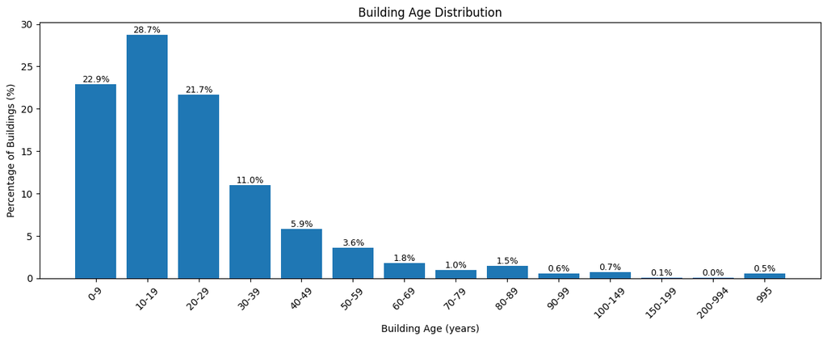

```python
bins = [-1, 9, 19, 29, 39, 49, 59, 69, 79, 89, 99, 149, 199, 994, 995]
labels = [f"{x}-{x+9}" for x in range(0, 100, 10)] + ["100-149", "150-199", "200-994", "995"]

age_pct = (
    pd.cut(X["age"], bins=bins, labels=labels, include_lowest=True)
    .value_counts(sort=False)
    .div(len(X))
    .mul(100)
)

plt.figure(figsize=(12, 5))
bars = plt.bar(age_pct.index.astype(str), age_pct)

plt.title("Building Age Distribution")
plt.xlabel("Building Age (years)")
plt.ylabel("Percentage of Buildings (%)")
plt.xticks(rotation=45)

for bar, pct in zip(bars, age_pct):
    if pct:
        plt.text(
            bar.get_x() + bar.get_width() / 2,
            bar.get_height(),
            f"{pct:.1f}%",
            ha="center",
            va="bottom",
            fontsize=9
        )

plt.tight_layout()
plt.show()
```

### 1.3 Explore

With data-quality issues identified, we explore feature distributions and their relationship with the target variable.

#### 1.3.1 Target Distribution

The target distribution is important because the three damage grades are not equally represented.

Both absolute counts and percentages are examined before evaluating models.

```python
import matplotlib.pyplot as plt


target_counts = y.value_counts().sort_index()
target_percent = y.value_counts(normalize=True).sort_index() * 100

target_summary = pd.DataFrame({
    "count": target_counts,
    "percentage": target_percent
})

target_summary
```

| damage_grade | count | percentage |
| --- | --- | --- |
| 1 | 25124 | 9.640792 |
| 2 | 148259 | 56.891186 |
| 3 | 87218 | 33.468022 |

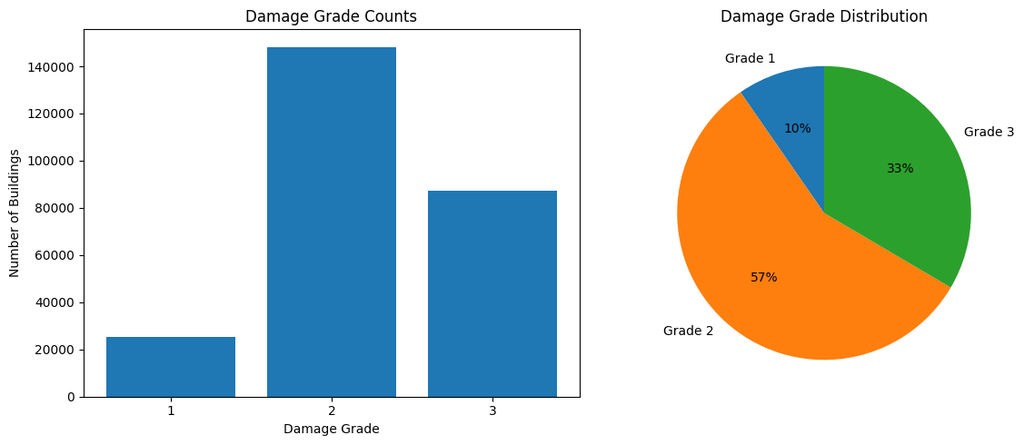

```python
fig, axes = plt.subplots(1, 2, figsize=(12, 5))

axes[0].bar(
    target_summary.index.astype(str),
    target_summary["count"]
)

axes[0].set_title("Damage Grade Counts")
axes[0].set_xlabel("Damage Grade")
axes[0].set_ylabel("Number of Buildings")

axes[1].pie(
    target_summary["count"],
    labels=[f"Grade {i}" for i in target_summary.index],
    autopct="%1.0f%%",
    startangle=90
)

axes[1].set_title("Damage Grade Distribution")

plt.tight_layout()
plt.show()
```

**Interpretation**

- The target is imbalanced: Grade 1 (low damage) is a minority at 9.64% (25,124 buildings), Grade 2 (medium damage) dominates at 56.89% (148,259), and Grade 3 (near-total destruction) makes up 33.47% (87,218).
- Because Micro-F1 is equivalent to accuracy for this single-label problem, a naive "always predict Grade 2" baseline would already score ~56.9%, so this class imbalance alone could make accuracy-style metrics look deceptively high without the Low- and Severe-damage classes being distinguished well.
- Given this skew, Macro-F1 is a useful diagnostic metric alongside Micro-F1 for judging performance on the minority Grade 1 class — since the competition's official evaluation metric is Micro-F1 (equivalent to accuracy here), Macro-F1 should supplement rather than replace it when tracking model performance. Any train/validation split would probably need to be stratified to keep class proportions consistent across both sets.

#### 1.3.2 Geographic Features

The three geographic variables form a nested hierarchy:

- `geo_level_1_id`
- `geo_level_2_id`
- `geo_level_3_id`

They are identifiers rather than continuous measurements, so their cardinality and relationship with damage grade are more informative than their numeric values themselves.

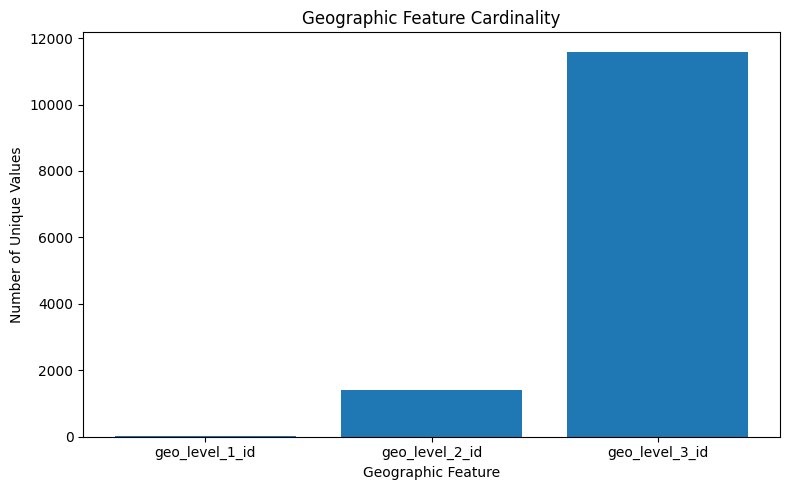

```python
geo_cardinality = pd.DataFrame({
    "feature": GEO_COLS,
    "unique_values": [
        train_values[col].nunique()
        for col in GEO_COLS
    ]
})

#geo_cardinality

plt.figure(figsize=(8, 5))

plt.bar(
    geo_cardinality["feature"],
    geo_cardinality["unique_values"]
)

plt.title("Geographic Feature Cardinality")
plt.xlabel("Geographic Feature")
plt.ylabel("Number of Unique Values")

plt.tight_layout()
plt.show()
```

```python
import pandas as pd
import plotly.graph_objects as go


# =========================================================
# Stratified-looking geographic sample
# =========================================================

GEO_SAMPLE_SIZE = 5000

geo_data = X[
    [
        "geo_level_1_id",
        "geo_level_2_id",
        "geo_level_3_id"
    ]
].copy()

# Calculate proportional sample size for each Geo 1 → Geo 2 group
group_sizes = (
    geo_data
    .groupby(
        ["geo_level_1_id", "geo_level_2_id"]
    )
    .size()
    .reset_index(name="count")
)

group_sizes["sample_n"] = (
    group_sizes["count"]
    .div(len(geo_data))
    .mul(GEO_SAMPLE_SIZE)
    .round()
    .astype(int)
    .clip(lower=1)
)

sampled_groups = []

for _, group in group_sizes.iterrows():

    mask = (
        (geo_data["geo_level_1_id"] == group["geo_level_1_id"]) &
        (geo_data["geo_level_2_id"] == group["geo_level_2_id"])
    )

    group_data = geo_data.loc[mask]

    sampled_groups.append(
        group_data.sample(
            n=min(group["sample_n"], len(group_data)),
            random_state=RANDOM_STATE
        )
    )

geo_sample = (
    pd.concat(sampled_groups)
    .sample(
        n=min(GEO_SAMPLE_SIZE, len(pd.concat(sampled_groups))),
        random_state=RANDOM_STATE
    )
    .reset_index(drop=True)
)

geo_sample = geo_sample.astype(str)

# =========================================================
# 2. Count observations at each hierarchy level
# =========================================================

geo1 = (
    geo_sample
    .groupby("geo_level_1_id")
    .size()
)

geo2 = (
    geo_sample
    .groupby(
        ["geo_level_1_id", "geo_level_2_id"]
    )
    .size()
)

geo3 = (
    geo_sample
    .groupby(
        [
            "geo_level_1_id",
            "geo_level_2_id",
            "geo_level_3_id"
        ]
    )
    .size()
)


# =========================================================
# 3. Build sunburst nodes
# =========================================================

ids = []
labels = []
parents = []
values = []
hover_text = []


# ---------------------------------------------------------
# Geo Level 1
# ---------------------------------------------------------

for geo1_id, count in geo1.items():

    node_id = f"geo1_{geo1_id}"

    ids.append(node_id)
    labels.append(f"geo_level_1_id = {geo1_id}")
    parents.append("")
    values.append(count)

    hover_text.append(
        f"<b>geo_level_1_id = {geo1_id}</b>"
        f"<br>Buildings in sample: {count}"
    )


# ---------------------------------------------------------
# Geo Level 2
# ---------------------------------------------------------

for (geo1_id, geo2_id), count in geo2.items():

    node_id = f"geo2_{geo1_id}_{geo2_id}"
    parent_id = f"geo1_{geo1_id}"

    ids.append(node_id)
    labels.append(f"geo_level_2_id = {geo2_id}")
    parents.append(parent_id)
    values.append(count)

    hover_text.append(
        f"<b>geo_level_2_id = {geo2_id}</b>"
        f"<br>geo_level_1_id = {geo1_id}"
        f"<br>Buildings in sample: {count}"
    )


# ---------------------------------------------------------
# Geo Level 3
# ---------------------------------------------------------

for (
    geo1_id,
    geo2_id,
    geo3_id
), count in geo3.items():

    node_id = (
        f"geo3_{geo1_id}_{geo2_id}_{geo3_id}"
    )

    parent_id = (
        f"geo2_{geo1_id}_{geo2_id}"
    )

    ids.append(node_id)
    labels.append(f"geo_level_3_id = {geo3_id}")
    parents.append(parent_id)
    values.append(count)

    hover_text.append(
        f"<b>geo_level_3_id = {geo3_id}</b>"
        f"<br>geo_level_2_id = {geo2_id}"
        f"<br>geo_level_1_id = {geo1_id}"
        f"<br>Buildings in sample: {count}"
    )


# =========================================================
# 4. Create figure
# =========================================================

fig = go.Figure(
    go.Sunburst(
        ids=ids,
        labels=labels,
        parents=parents,
        values=values,
        branchvalues="total",
        customdata=hover_text,
        hovertemplate=(
            "%{customdata}"
            "<extra></extra>"
        )
    )
)


# =========================================================
# 5. Layout
# =========================================================

fig.update_layout(
    title=(
        "Geographic Hierarchy: "
        "Geo Level 1 → Geo Level 2 → Geo Level 3"
    ),
    width=950,
    height=850,
    margin=dict(
        t=80,
        l=20,
        r=20,
        b=20
    )
)

fig.show()
```

[output not shown]

```python
#Check hierarchy:

geo3_parent_check = (
    train_values
    .groupby("geo_level_3_id")["geo_level_2_id"]
    .nunique()
)

geo2_parent_check = (
    train_values
    .groupby("geo_level_2_id")["geo_level_1_id"]
    .nunique()
)

print(
    "geo_level_3 IDs with multiple geo_level_2 parents:",
    (geo3_parent_check > 1).sum()
)

print(
    "geo_level_2 IDs with multiple geo_level_1 parents:",
    (geo2_parent_check > 1).sum()
)
```

```
geo_level_3 IDs with multiple geo_level_2 parents: 0
geo_level_2 IDs with multiple geo_level_1 parents: 0
```

**Interpretation**

- Cardinality increases sharply down the geographic hierarchy: `geo_level_1_id` has 31 unique values, `geo_level_2_id` has 1,414, and `geo_level_3_id` has 11,595 — roughly a 45x and 8x increase at each finer level.
- The hierarchy-check confirms the three levels are perfectly nested (0 `geo_level_3_id`s map to more than one `geo_level_2_id` parent, and 0 `geo_level_2_id`s map to more than one `geo_level_1_id` parent), so each finer geographic ID uniquely rolls up into a single coarser region.
- This nesting matters for the damage-grade relationship uncovered later: `geo_level_3_id` turns out to be the single strongest predictor of `damage_grade` in both the association (Cramér's V 0.555) and mutual-information analyses, and even the coarse `geo_level_1_id` alone reaches 0.373 — location captures shaking intensity, soil conditions, and local construction practice, which appears to dominate the damage outcome more than any individual building attribute.

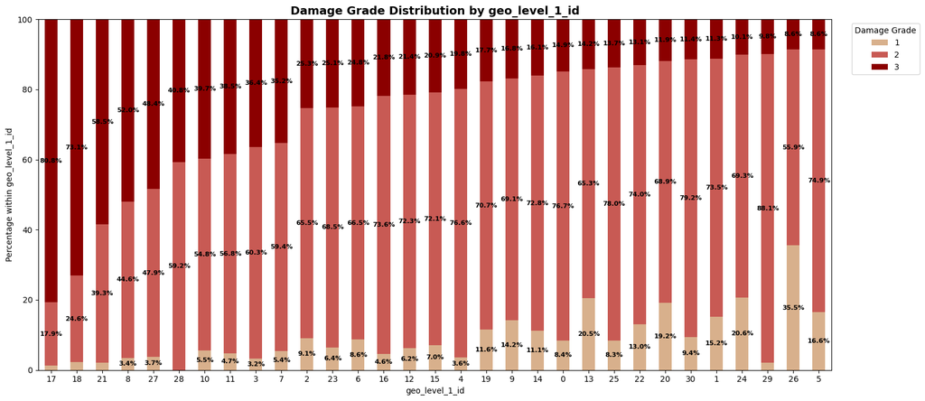

```python
# =============================================================
# Geo Level 1 — Damage Grade Distribution
# =============================================================

geo1_damage = pd.crosstab(
    X["geo_level_1_id"],
    y,
    normalize="index"
) * 100

geo1_damage = geo1_damage.reindex(
    columns=[1, 2, 3],
    fill_value=0
)

# Order geographic regions by Grade 3 damage
geo1_damage = geo1_damage.sort_values(
    by=3,
    ascending=False
)

# -------------------------------------------------------------
# Damage grade colors
# -------------------------------------------------------------

damage_colors = [
    "#D8B08C",   # Grade 1 — light brown
    "#C85A54",   # Grade 2 — medium red
    "#8B0000"    # Grade 3 — dark red
]

# -------------------------------------------------------------
# Plot
# -------------------------------------------------------------

ax = geo1_damage.plot(
    kind="bar",
    stacked=True,
    figsize=(16, 7),
    color=damage_colors
)

# -------------------------------------------------------------
# Percentage labels
# -------------------------------------------------------------

for container in ax.containers:

    labels = []

    for bar in container:
        height = bar.get_height()

        if height >= 3:
            labels.append(f"{height:.1f}%")
        else:
            labels.append("")

    ax.bar_label(
        container,
        labels=labels,
        label_type="center",
        fontsize=8,
        fontweight="bold",
        color="black"
    )

# -------------------------------------------------------------
# Formatting
# -------------------------------------------------------------

ax.set_title(
    "Damage Grade Distribution by geo_level_1_id",
    fontsize=14,
    fontweight="bold"
)

ax.set_xlabel(
    "geo_level_1_id"
)

ax.set_ylabel(
    "Percentage within geo_level_1_id"
)

ax.set_ylim(0, 100)

ax.tick_params(
    axis="x",
    rotation=0
)

ax.legend(
    title="Damage Grade",
    loc="upper left",
    bbox_to_anchor=(1.02, 1)
)

plt.tight_layout()

plt.show()
```

**Interpretation**

- Severe-damage (Grade 3) share varies enormously across the 31 `geo_level_1_id` regions — from roughly 8-9% in the safest regions (e.g. ids 26, 5, 29) up to roughly 75-80% in the hardest-hit regions (ids 17, 18), a nearly 10x range.
- This spread is far wider than anything seen among the individual categorical or numeric building features, which is why `geo_level_1_id` alone already reaches a Cramér's V of 0.373, rising to 0.555 for the more granular `geo_level_3_id`.
- It strongly suggests that regional differences in earthquake shaking intensity, soil conditions, and/or local construction standards are the dominant driver of damage outcomes in this dataset — more so than any single building-level attribute.

#### 1.3.3 Numeric Feature Summary

The distributions and summary statistics of the continuous/count variables are inspected below.

Special attention is given to `age`, where unusually large values may represent special survey codes rather than realistic building ages.

### Feature Characteristics

| Feature | Description | Possible Values |
| --- | --- | --- |
| `count_floors_pre_eq` | Number of floors in the building before the earthquake. | 1-9 |
| `age` | Age of the building in years. | 0-995 (995 is a likely sentinel/special survey code, not a real age) |
| `area_percentage` | Normalized area of the building footprint. | 1-100 |
| `height_percentage` | Normalized height of the building footprint. | 2-32 |
| `count_families` | Number of families that live in the building. | 0-9 |

```python
X[NUMERIC_COLS].describe().T
```

|  | count | mean | std | min | 25% | 50% | 75% | max |
| --- | --- | --- | --- | --- | --- | --- | --- | --- |
| count_floors_pre_eq | 260601.0 | 2.129723 | 0.727665 | 1.0 | 2.0 | 2.0 | 2.0 | 9.0 |
| age | 260601.0 | 26.535029 | 73.565937 | 0.0 | 10.0 | 15.0 | 30.0 | 995.0 |
| area_percentage | 260601.0 | 8.018051 | 4.392231 | 1.0 | 5.0 | 7.0 | 9.0 | 100.0 |
| height_percentage | 260601.0 | 5.434365 | 1.918418 | 2.0 | 4.0 | 5.0 | 6.0 | 32.0 |
| count_families | 260601.0 | 0.983949 | 0.418389 | 0.0 | 1.0 | 1.0 | 1.0 | 9.0 |

**Interpretation**

- `count_floors_pre_eq` is tightly distributed (mean 2.13, std 0.73, range 1-9), with most buildings having 2 floors.
- `area_percentage` (mean 8.0, range 1-100) and `height_percentage` (mean 5.4, range 2-32) are both right-skewed footprint/height proxies.
- `count_families` is almost always exactly 1 (mean 0.98, std 0.42, range 0-9), meaning it carries very little variance to explain damage outcomes.
- `age` stands out: the mean (26.5) is far above the median (15), and the max (995) is wildly inconsistent with the 75th percentile (30), signalling a heavy right skew driven by extreme outliers.

#### 1.3.4 Categorical Feature Value Counts and Damage Distribution

For each categorical feature we examine:

1. The prevalence of each category.
2. The damage-grade distribution within each category.

This helps identify categorical variables with substantial differences in damage outcomes.

### Feature Characteristics

| Feature | Description | Possible Values (code -> meaning[1]) |
| --- | --- | --- |
| `land_surface_condition` | Surface condition of the land where the building was built. | `n` -> Flat `o` -> Moderate slope / obstructed `t` -> Steep slope / terraced |
| `foundation_type` | Type of foundation used while building. | `h` -> Mud mortar-stone/brick `i` -> Bamboo/timber `r` -> Cement/RC `u` -> Unknown `w` -> Other |
| `roof_type` | Type of roof used while building. | `n` -> Bamboo/timber (light roof) `q` -> Bamboo/timber (heavy roof) `x` -> RCC/RB/RBC |
| `ground_floor_type` | Type of the ground floor. | `f` -> Mud `m` -> Timber `v` -> RCC `x` -> Brick/stone `z` -> Other |
| `other_floor_type` | Type of construction used in floors higher than the ground floor (excluding roof). | `j` -> Timber/bamboo-mud `q` -> Timber planck `s` -> RCC/RB/RBC `x` -> Not applicable |
| `position` | Position of the building. | `j` -> Attached on one side `o` -> Not attached / stand-alone `s` -> Attached on two sides `t` -> Attached on three sides / corner |
| `plan_configuration` | Building plan configuration. | `a` -> Square `c` -> Rectangular `d` -> T-shaped / cross-shaped `f` -> L-shaped `m` -> Multi-projected `n` -> T-shaped `o` -> Other `q` -> U-shaped `s` -> Irregular `u` -> Unknown |
| `legal_ownership_status` | Legal ownership status of the land where the building was built. | `a` -> Private `r` -> Rented `v` -> Other `w` -> Government |

> Full code-to-meaning reference: `Categorical_Feature_Codes.md` [1] https://huggingface.co/un1u3/seismosafe-nepal

```python
def categorical_damage_analysis(df, target, feature):
    """Plot category prevalence and damage-grade distribution."""

    # Category prevalence
    value_pct = (
        df[feature]
        .value_counts(normalize=True)
        .sort_values(ascending=False) * 100
    )
    category_order = value_pct.index

    # Damage-grade distribution
    damage_pct = (
        pd.crosstab(df[feature], target, normalize="index") * 100
    ).reindex(
        index=category_order,
        columns=[1, 2, 3],
        fill_value=0
    )

    # Plot
    fig, axes = plt.subplots(1, 2, figsize=(16, 5))

    # ---------------------------------------------------------
    # Category prevalence
    # ---------------------------------------------------------
    value_pct.plot(kind="barh", ax=axes[0])
    axes[0].invert_yaxis()

    for bar in axes[0].patches:
        width = bar.get_width()
        y = bar.get_y() + bar.get_height() / 2

        axes[0].text(
            width / 2 if width > 5 else width + 0.3,
            y,
            f"{width:.1f}%",
            ha="center" if width > 5 else "left",
            va="center",
            fontsize=9,
            fontweight="bold",
            color="black"
        )

    axes[0].set_title(f"{feature} — Category Prevalence")
    axes[0].set_xlabel("Percentage of Buildings")
    axes[0].set_ylabel(feature)

    # ---------------------------------------------------------
    # Damage-grade distribution
    # ---------------------------------------------------------
    damage_colors = ["#D8B08C", "#C85A54", "#8B0000"]

    damage_pct.plot(
        kind="barh",
        stacked=True,
        ax=axes[1],
        color=damage_colors
    )
    axes[1].invert_yaxis()

    for bar in axes[1].patches:
        width = bar.get_width()

        if width >= 3:
            axes[1].text(
                bar.get_x() + width / 2,
                bar.get_y() + bar.get_height() / 2,
                f"{width:.1f}%",
                ha="center",
                va="center",
                fontsize=9,
                fontweight="bold",
                color="black"
            )

    axes[1].set_title(f"{feature} — Damage Grade Distribution")
    axes[1].set_xlabel("Percentage within Category")
    axes[1].set_ylabel(feature)

    axes[1].legend(
        title="Damage Grade",
        loc="upper left",
        bbox_to_anchor=(1.02, 1)
    )

    plt.tight_layout(rect=[0, 0, 0.90, 1])
    plt.show()

    return value_pct, damage_pct
```

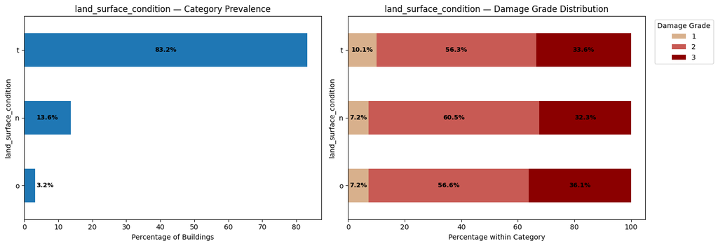

```python
categorical_results = {}

feature = "land_surface_condition"

value_pct, damage_pct = categorical_damage_analysis(X, y, feature)

categorical_results[feature] = {
    "prevalence": value_pct,
    "damage_distribution": damage_pct,
}
```

**Interpretation** (prevalence -> Grade 1 / Grade 2 / Grade 3 split)

- **`land_surface_condition`**: dominated by `t` (steep slope / terraced, 83.2%, 10.1/56.3/33.6), with `n` (flat, 13.6%) and `o` (moderate slope / obstructed, 3.2%) showing only small shifts in damage share. This is one of the weakest categorical signals, consistent with its near-zero mutual information (0.001) later in the EDA.

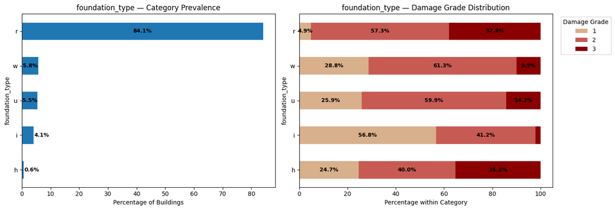

```python
feature = "foundation_type"

value_pct, damage_pct = categorical_damage_analysis(X, y, feature)

categorical_results[feature] = {
    "prevalence": value_pct,
    "damage_distribution": damage_pct,
}
```

**Interpretation** (prevalence -> Grade 1 / Grade 2 / Grade 3 split)

- **`foundation_type`**: shows the widest swing of any categorical feature. The dominant `r` foundation (cement/RC, 84.1% of buildings) has the highest severe-damage share (37.8%), while `w` (other, 5.8%) and `u` (unknown, 5.5%) foundations see far less Grade 3 damage (9.9% and 14.2%), and `i` foundations (bamboo/timber, 4.1%) are the safest overall (56.8% Grade 1, negligible Grade 3).

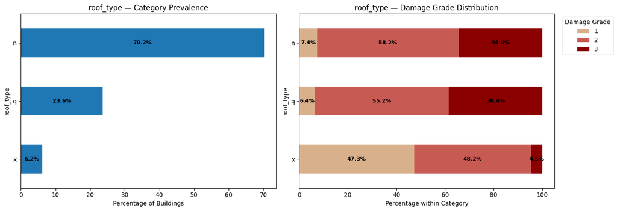

```python
feature = "roof_type"

value_pct, damage_pct = categorical_damage_analysis(X, y, feature)

categorical_results[feature] = {
    "prevalence": value_pct,
    "damage_distribution": damage_pct,
}
```

**Interpretation** (prevalence -> Grade 1 / Grade 2 / Grade 3 split)

- **`roof_type`**: the minority `x` roof (RCC/RB/RBC, 6.2% of buildings) has dramatically lower severe damage (4.5%) than the dominant `n` (bamboo/timber, light roof, 70.2%, 34.4% Grade 3) and `q` (bamboo/timber, heavy roof, 23.6%, 38.4% Grade 3), pointing to a more resilient roofing style.

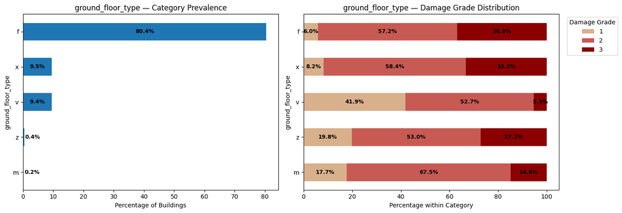

```python
feature = "ground_floor_type"

value_pct, damage_pct = categorical_damage_analysis(X, y, feature)

categorical_results[feature] = {
    "prevalence": value_pct,
    "damage_distribution": damage_pct,
}
```

**Interpretation** (prevalence -> Grade 1 / Grade 2 / Grade 3 split)

- **`ground_floor_type`**: minority type `v` (RCC, 9.4%) shows much lower severe damage (5.3%) than the dominant `f` (mud, 80.4%, 36.9% Grade 3), again suggesting a sturdier construction material for that category.

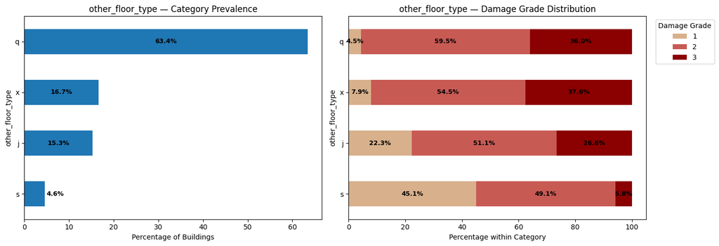

```python
feature = "other_floor_type"

value_pct, damage_pct = categorical_damage_analysis(X, y, feature)

categorical_results[feature] = {
    "prevalence": value_pct,
    "damage_distribution": damage_pct,
}
```

**Interpretation** (prevalence -> Grade 1 / Grade 2 / Grade 3 split)

- **`other_floor_type`**: minority type `s` (RCC/RB/RBC, 4.6%) sustains far less severe damage (5.8%) than the dominant `q` (timber planck, 63.4%, 36.0% Grade 3), reinforcing that floor/roof construction material is a consistent damage signal.

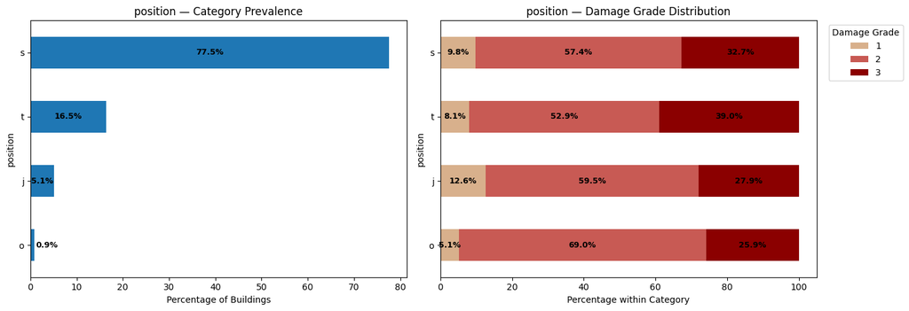

```python
feature = "position"

value_pct, damage_pct = categorical_damage_analysis(X, y, feature)

categorical_results[feature] = {
    "prevalence": value_pct,
    "damage_distribution": damage_pct,
}
```

**Interpretation** (prevalence -> Grade 1 / Grade 2 / Grade 3 split)

- **`position`**: mildest gradient among the structural categoricals (Grade 3 share ranges ~26-39% across categories `j` attached on one side, `o` not attached / stand-alone, `s` attached on two sides, `t` attached on three sides / corner), so building position is a secondary risk factor at best.

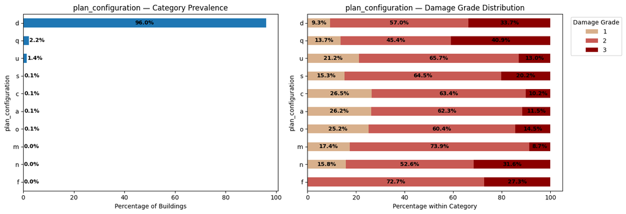

```python
feature = "plan_configuration"

value_pct, damage_pct = categorical_damage_analysis(X, y, feature)

categorical_results[feature] = {
    "prevalence": value_pct,
    "damage_distribution": damage_pct,
}
```

**Interpretation** (prevalence -> Grade 1 / Grade 2 / Grade 3 split)

- **`plan_configuration`**: 96.0% of buildings use the `d` configuration (T-shaped / cross-shaped), whose damage split (9.3/57.0/33.7) closely matches the overall population baseline (9.6/56.9/33.5); rarer configurations (e.g. `q` at 2.2% with 40.9% Grade 3, U-shaped) deviate more but are based on very small samples.

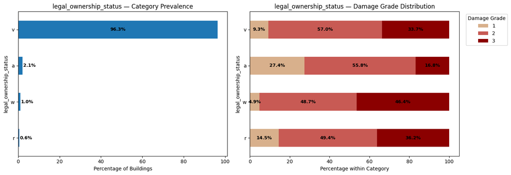

```python
feature = "legal_ownership_status"

value_pct, damage_pct = categorical_damage_analysis(X, y, feature)

categorical_results[feature] = {
    "prevalence": value_pct,
    "damage_distribution": damage_pct,
}
```

**Interpretation** (prevalence -> Grade 1 / Grade 2 / Grade 3 split)

- **`legal_ownership_status`**: 96.3% of buildings are `v` (other, matching the population baseline), while the rare `w` category (government, 1.0%) shows a notably higher severe-damage rate (46.4%) — likely a proxy for geography or construction quality rather than a causal effect of ownership itself.
- **Overall**: `foundation_type`, `ground_floor_type`, `other_floor_type`, and `roof_type` produce the largest swings in damage-grade share and rank highest among the categorical features in the later association/mutual-information analysis, while `land_surface_condition`, `position`, `plan_configuration`, and `legal_ownership_status` are comparatively flat and uninformative once the dominant category's small sample edge cases are set aside.

#### 1.3.5 Binary Structural and Secondary-Use Features

Binary indicators describe structural materials and secondary building use.

This covers:

- Prevalence of superstructure materials
- Prevalence of secondary-use categories
- Number of superstructure flags set per building
- Damage distribution across geographic regions

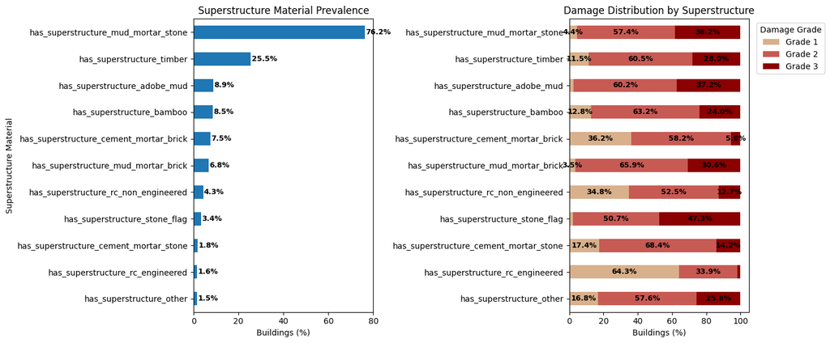

```python
prevalence = (
    X[SUPERSTRUCTURE_COLS]
    .mean()
    .mul(100)
    .sort_values()
)

damage = (
    X[SUPERSTRUCTURE_COLS]
    .assign(damage_grade=y.values)
    .melt(
        "damage_grade",
        var_name="superstructure",
        value_name="present"
    )
    .query("present == 1")
    .groupby(["superstructure", "damage_grade"])
    .size()
    .groupby(level=0)
    .transform(lambda x: x / x.sum() * 100)
    .rename("percentage")
    .reset_index()
    .pivot(
        index="superstructure",
        columns="damage_grade",
        values="percentage"
    )
    .fillna(0)
    .reindex(prevalence.index)
)

fig, axes = plt.subplots(
    1, 2,
    figsize=(16, 6)
)

# ---------------------------------------------------------
# Superstructure prevalence
# ---------------------------------------------------------

prevalence.plot(
    kind="barh",
    ax=axes[0]
)

axes[0].set_title("Superstructure Material Prevalence")
axes[0].set_xlabel("Buildings (%)")
axes[0].set_ylabel("Superstructure Material")

# Percentage labels
for bar in axes[0].patches:
    width = bar.get_width()

    axes[0].text(
        width + 0.3,
        bar.get_y() + bar.get_height() / 2,
        f"{width:.1f}%",
        ha="left",
        va="center",
        fontsize=9,
        fontweight="bold",
        color="black"
    )


# ---------------------------------------------------------
# Damage distribution
# ---------------------------------------------------------

damage_colors = [
    "#D8B08C",   # Grade 1
    "#C85A54",   # Grade 2
    "#8B0000"    # Grade 3
]

damage[[1, 2, 3]].plot(
    kind="barh",
    stacked=True,
    ax=axes[1],
    color=damage_colors
)

axes[1].set_title("Damage Distribution by Superstructure")
axes[1].set_xlabel("Buildings (%)")
axes[1].set_ylabel("")

# Percentage labels
for bar in axes[1].patches:
    width = bar.get_width()

    if width < 3:
        continue

    axes[1].text(
        bar.get_x() + width / 2,
        bar.get_y() + bar.get_height() / 2,
        f"{width:.1f}%",
        ha="center",
        va="center",
        fontsize=9,
        fontweight="bold",
        color="black"
    )

# Legend outside the plot
axes[1].legend(
    title="Damage Grade",
    labels=["Grade 1", "Grade 2", "Grade 3"],
    loc="upper left",
    bbox_to_anchor=(1.02, 1)
)

plt.tight_layout(
    rect=[0, 0, 0.90, 1]
)

plt.show()
```

**Interpretation**

- `has_superstructure_mud_mortar_stone` is by far the dominant material (~76% of buildings), followed by `has_superstructure_timber` (~26%); reinforced-concrete indicators (`has_superstructure_rc_engineered` ~2%, `has_superstructure_rc_non_engineered` ~4%) are rare.
- Because a building can carry multiple superstructure flags, this reflects a construction landscape heavily weighted toward informal/traditional materials and only lightly toward earthquake-resistant engineered concrete — consistent with the overall skew toward Grade 2/3 damage seen in the target distribution.
- `has_superstructure_mud_mortar_stone` has the highest association with `damage_grade` of any binary indicator, so its very high prevalence is a major contributor to the dataset's damage outcomes.

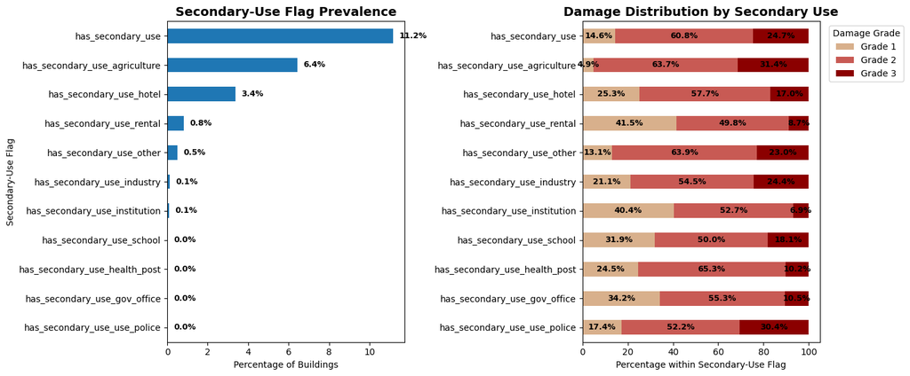

```python
# Secondary use

prevalence = (
    X[SECONDARY_USE_COLS]
    .mean()
    .mul(100)
    .sort_values()
)

damage = (
    X[SECONDARY_USE_COLS]
    .assign(damage_grade=y.values)
    .melt(
        "damage_grade",
        var_name="secondary_use",
        value_name="present"
    )
    .query("present == 1")
    .groupby(["secondary_use", "damage_grade"])
    .size()
    .groupby(level=0)
    .transform(lambda x: x / x.sum() * 100)
    .rename("percentage")
    .reset_index()
    .pivot(
        index="secondary_use",
        columns="damage_grade",
        values="percentage"
    )
    .fillna(0)
    .reindex(prevalence.index)
)

fig, axes = plt.subplots(
    1, 2,
    figsize=(16, 6)
)

# ---------------------------------------------------------
# Secondary-use prevalence
# ---------------------------------------------------------

prevalence.plot(
    kind="barh",
    ax=axes[0]
)

for bar in axes[0].patches:
    width = bar.get_width()

    axes[0].text(
        width + 0.3,
        bar.get_y() + bar.get_height() / 2,
        f"{width:.1f}%",
        ha="left",
        va="center",
        fontsize=9,
        fontweight="bold",
        color="black"
    )

axes[0].set_title(
    "Secondary-Use Flag Prevalence",
    fontsize=14,
    fontweight="bold"
)
axes[0].set_xlabel("Percentage of Buildings")
axes[0].set_ylabel("Secondary-Use Flag")


# ---------------------------------------------------------
# Damage distribution
# ---------------------------------------------------------

damage_colors = [
    "#D8B08C",   # Grade 1
    "#C85A54",   # Grade 2
    "#8B0000"    # Grade 3
]

damage[[1, 2, 3]].plot(
    kind="barh",
    stacked=True,
    ax=axes[1],
    color=damage_colors
)

for bar in axes[1].patches:
    width = bar.get_width()

    if width < 3:
        continue

    axes[1].text(
        bar.get_x() + width / 2,
        bar.get_y() + bar.get_height() / 2,
        f"{width:.1f}%",
        ha="center",
        va="center",
        fontsize=9,
        fontweight="bold",
        color="black"
    )

axes[1].set_title(
    "Damage Distribution by Secondary Use",
    fontsize=14,
    fontweight="bold"
)
axes[1].set_xlabel("Percentage within Secondary-Use Flag")
axes[1].set_ylabel("")

axes[1].legend(
    title="Damage Grade",
    labels=["Grade 1", "Grade 2", "Grade 3"],
    loc="upper left",
    bbox_to_anchor=(1.02, 1)
)

plt.tight_layout(
    rect=[0, 0, 0.90, 1]
)

plt.show()
```

**Interpretation**

- Only ~11% of buildings report any secondary use (`has_secondary_use`), and within that, agriculture (~6.5%) and hotel (~3.3%) are the only sub-categories with meaningful prevalence; every other secondary-use flag affects well under 1% of buildings.
- Despite this rarity, `has_secondary_use_hotel` (0.108) and `has_secondary_use_rental` (0.101) still appear in the top-15 association ranking later in the EDA — this is more likely a proxy effect (hotels/rentals concentrated in specific geographic areas or building types) than a direct causal link between secondary use and structural damage.

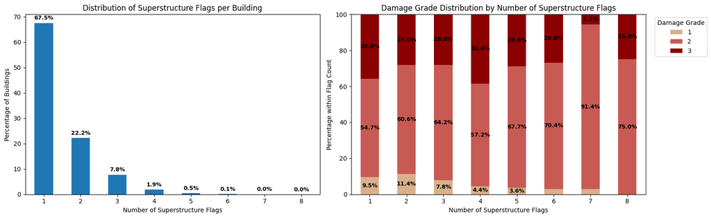

```python
# =============================================================
# Superstructure flag count + damage distribution
# =============================================================

superstructure_count = X[SUPERSTRUCTURE_COLS].sum(axis=1)

# -------------------------------------------------------------
# 1. Percentage distribution of number of flags
# -------------------------------------------------------------

flag_distribution = (
    superstructure_count
    .value_counts(normalize=True)
    .sort_index()
    * 100
)

# -------------------------------------------------------------
# 2. Damage-grade distribution for each flag count
# -------------------------------------------------------------

damage_by_flags = pd.crosstab(
    superstructure_count,
    y,
    normalize="index"
) * 100

# Ensure all damage grades are present
damage_by_flags = damage_by_flags.reindex(
    columns=[1, 2, 3],
    fill_value=0
)

# -------------------------------------------------------------
# 3. Plot
# -------------------------------------------------------------

fig, axes = plt.subplots(
    1,
    2,
    figsize=(16, 5)
)

# =============================================================
# LEFT: Flag count distribution
# =============================================================

flag_distribution.plot(
    kind="bar",
    ax=axes[0]
)

for container in axes[0].containers:
    axes[0].bar_label(
        container,
        fmt="%.1f%%",
        padding=3,
        fontsize=9,
        fontweight="bold",
        color="black"
    )

axes[0].set_title(
    "Distribution of Superstructure Flags per Building"
)

axes[0].set_xlabel(
    "Number of Superstructure Flags"
)

axes[0].set_ylabel(
    "Percentage of Buildings"
)

axes[0].tick_params(
    axis="x",
    rotation=0
)


# =============================================================
# RIGHT: Damage distribution
# =============================================================

damage_colors = [
    "#D8B08C",   # Grade 1 - light brown
    "#C85A54",   # Grade 2 - medium red
    "#8B0000"    # Grade 3 - dark red
]

damage_by_flags.plot(
    kind="bar",
    stacked=True,
    ax=axes[1],
    color=damage_colors
)

# Add percentage labels
for container in axes[1].containers:

    labels = []

    for bar in container:
        height = bar.get_height()

        if height >= 3:
            labels.append(f"{height:.1f}%")
        else:
            labels.append("")

    axes[1].bar_label(
        container,
        labels=labels,
        label_type="center",
        fontsize=9,
        fontweight="bold",
        color="black"
    )

axes[1].set_title(
    "Damage Grade Distribution by Number of Superstructure Flags"
)

axes[1].set_xlabel(
    "Number of Superstructure Flags"
)

axes[1].set_ylabel(
    "Percentage within Flag Count"
)

axes[1].set_ylim(0, 100)

axes[1].legend(
    title="Damage Grade",
    loc="upper left",
    bbox_to_anchor=(1.02, 1)
)

axes[1].tick_params(
    axis="x",
    rotation=0
)


# -------------------------------------------------------------
# Layout
# -------------------------------------------------------------

plt.tight_layout()

plt.show()
```

**Interpretation**

#### 1.3.6 Numeric Features and Damage Grade

The distributions of numeric variables are compared across the three damage grades.

This helps identify variables for which the distribution shifts systematically with increasing damage severity.

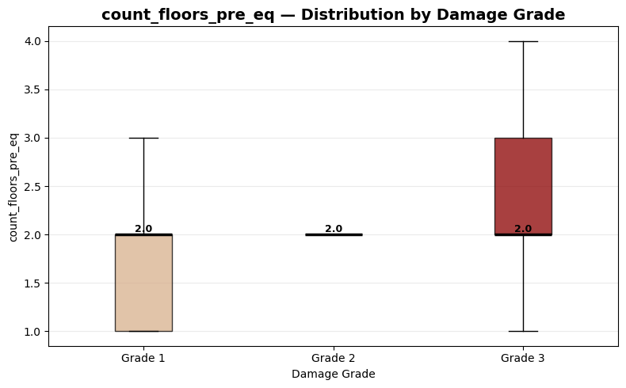

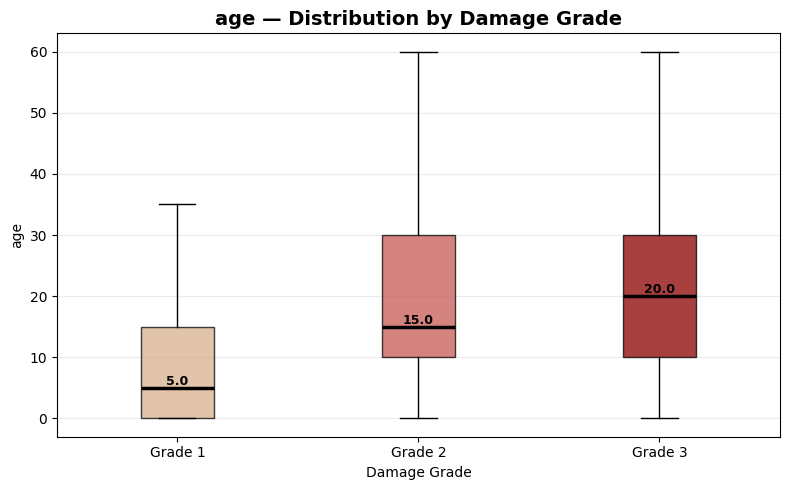

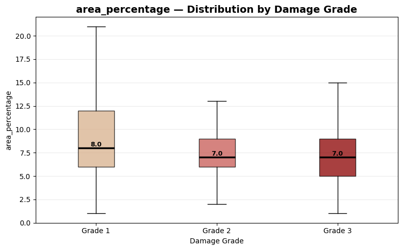

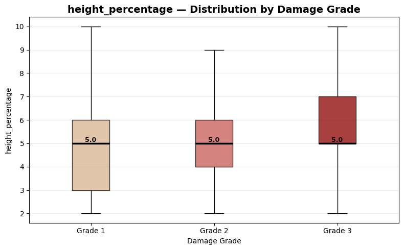

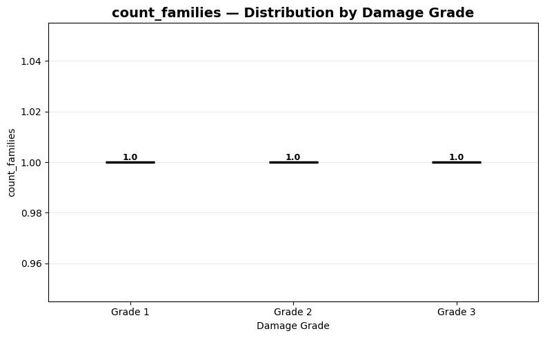

```python
import matplotlib.pyplot as plt

damage_colors = [
    "#D8B08C",   # Grade 1
    "#C85A54",   # Grade 2
    "#8B0000"    # Grade 3
]

grades = sorted(y.unique())

for feature in NUMERIC_COLS:

    data_by_grade = [
        X.loc[y == grade, feature].dropna()
        for grade in grades
    ]

    fig, ax = plt.subplots(figsize=(8, 5))

    bp = ax.boxplot(
        data_by_grade,
        patch_artist=True,
        tick_labels=[f"Grade {g}" for g in grades],
        showfliers=False
    )

    # ---------------------------------------------------------
    # Colour each box
    # ---------------------------------------------------------

    for box, color in zip(bp["boxes"], damage_colors):
        box.set_facecolor(color)
        box.set_alpha(0.75)

    # ---------------------------------------------------------
    # Median lines — black
    # ---------------------------------------------------------

    for median in bp["medians"]:
        median.set_color("black")
        median.set_linewidth(2.5)

    # ---------------------------------------------------------
    # Median value labels
    # ---------------------------------------------------------

    for i, data in enumerate(data_by_grade, start=1):

        median_value = data.median()

        ax.text(
            i,
            median_value,
            f"{median_value:.1f}",
            ha="center",
            va="bottom",
            fontsize=9,
            fontweight="bold",
            color="black"
        )

    # ---------------------------------------------------------
    # Formatting
    # ---------------------------------------------------------

    ax.set_title(
        f"{feature} — Distribution by Damage Grade",
        fontsize=14,
        fontweight="bold"
    )

    ax.set_xlabel("Damage Grade")
    ax.set_ylabel(feature)

    ax.grid(
        axis="y",
        alpha=0.25
    )

    plt.tight_layout()
    plt.show()
```

**Interpretation**

- **`age`** shows the clearest ordinal relationship: median age rises monotonically with damage severity (Grade 1 median 5 -> Grade 2 median 15 -> Grade 3 median 20), i.e. older buildings trend toward more severe damage.
- **`count_floors_pre_eq`** has the same median (2) across all three grades, but Grade 3 has a visibly wider spread (IQR extending to 3, whisker to 4 floors) compared to Grade 1 (whisker to 3), suggesting taller buildings are over-represented among severe-damage cases.
- **`height_percentage`** is flat at a median of 5 for every grade, but again Grade 3's IQR (5-7) sits above Grade 1's (3-6), a mild version of the same "taller buildings skew toward more damage" pattern.
- **`area_percentage`** shows only a weak, non-monotonic shift (median 8 for Grade 1 vs 7 for Grade 2 and Grade 3).
- **`count_families`** is constant at a median of 1 across all grades, carrying essentially no signal — consistent with it being almost always exactly 1 family per building (from the earlier describe table).
- Overall, `age` and `count_floors_pre_eq` are the most informative numeric features, but all five numeric variables rank below the geographic and structural-material features in both the association test (max |Pearson r| 0.125 for `area_percentage`) and mutual information analyses later in the EDA.

#### 1.3.7 Correlation and Collinearity

Pearson correlation is meaningful for continuous/count variables and binary indicators, but not for categorical labels or geographic IDs.

The correlation matrix therefore uses only the numeric and binary features.

Pairs with absolute correlation above 0.80 are flagged as a simple collinearity screening rule. This is a diagnostic threshold rather than an automatic feature-removal rule.

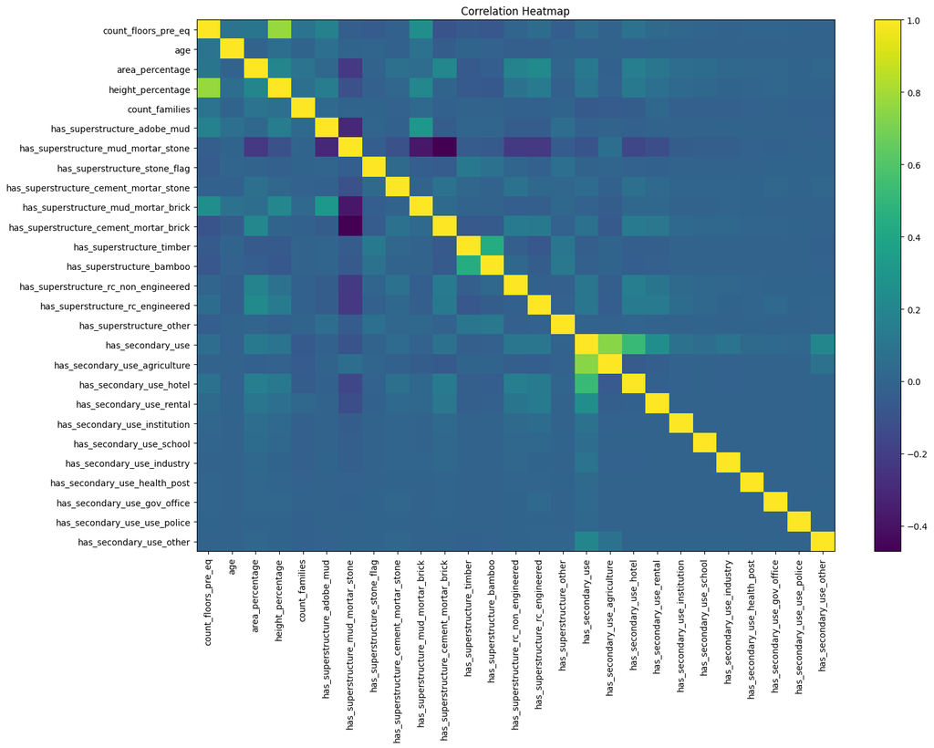

```python
CORRELATION_COLS = [
    *NUMERIC_COLS,
    *BINARY_COLS,
]

correlation_matrix = X[CORRELATION_COLS].corr()

plt.figure(figsize=(16, 12))

plt.imshow(
    correlation_matrix,
    aspect="auto"
)

plt.colorbar()

plt.xticks(
    range(len(CORRELATION_COLS)),
    CORRELATION_COLS,
    rotation=90
)

plt.yticks(
    range(len(CORRELATION_COLS)),
    CORRELATION_COLS
)

plt.title("Correlation Heatmap")

plt.tight_layout()
plt.show()
```

```python
# =============================================================
# Collinearity check
# =============================================================

CORR_THRESHOLD = 0.80

# -------------------------------------------------------------
# Keep only upper triangle
# -------------------------------------------------------------

upper_triangle = correlation_matrix.where(
    np.triu(
        np.ones(correlation_matrix.shape),
        k=1
    ).astype(bool)
)

# -------------------------------------------------------------
# Convert correlation matrix to feature pairs
# -------------------------------------------------------------

corr_pairs = (
    upper_triangle
    .stack()
    .reset_index()
)

corr_pairs.columns = [
    "Feature 1",
    "Feature 2",
    "Correlation"
]

# -------------------------------------------------------------
# Keep highly correlated pairs
# -------------------------------------------------------------

high_corr_pairs = (
    corr_pairs[
        corr_pairs["Correlation"].abs() >= CORR_THRESHOLD
    ]
    .sort_values(
        "Correlation",
        key=lambda s: s.abs(),
        ascending=False
    )
    .reset_index(drop=True)
)

# -------------------------------------------------------------
# Display result
# -------------------------------------------------------------

if high_corr_pairs.empty:

    print(
        f"No feature pairs have an absolute correlation "
        f"greater than or equal to {CORR_THRESHOLD:.2f}."
    )

else:

    print(
        f"Feature pairs with |correlation| >= "
        f"{CORR_THRESHOLD:.2f}:"
    )

    display(high_corr_pairs)
```

```
No feature pairs have an absolute correlation greater than or equal to 0.80.
```

**Interpretation**

- The heatmap's brightest off-diagonal cell is `count_floors_pre_eq` vs `height_percentage` (a naturally expected positive relationship, since more floors generally means a taller building), and `has_secondary_use` vs `has_secondary_use_agriculture` / `has_secondary_use_hotel` are also elevated, since the umbrella flag is set whenever any sub-flag is.
- The darkest (most negative) cells are among the superstructure material flags — e.g. `has_superstructure_mud_mortar_stone` vs `has_superstructure_cement_mortar_brick` — reflecting that these are largely mutually exclusive construction choices (a building built with one material is less likely to also use a competing one) rather than true redundancy.
- The explicit check confirms **no feature pair reaches |correlation| >= 0.80**, so no numeric/binary features need to be dropped for collinearity before modelling — all of them can be retained, which particularly matters for the linear/logistic baseline.

#### 1.3.8 Feature Association with Damage Grade

Different feature types require different association measures:

- Categorical and binary variables → **Cramér's V**
- Continuous/count variables → **absolute Pearson correlation**

Geographic IDs are treated as categorical variables because their numerical values are identifiers rather than continuous quantities.

```python
from scipy.stats import chi2_contingency


def cramers_v(x, y):
    """Calculate Cramér's V for two categorical variables."""

    confusion = pd.crosstab(x, y)

    chi2 = chi2_contingency(confusion)[0]

    n = confusion.sum().sum()
    phi2 = chi2 / n

    r, k = confusion.shape

    phi2_corrected = max(
        0,
        phi2 - ((k - 1) * (r - 1)) / (n - 1)
    )

    r_corrected = (
        r
        - ((r - 1) ** 2) / (n - 1)
    )

    k_corrected = (
        k
        - ((k - 1) ** 2) / (n - 1)
    )

    denominator = min(
        k_corrected - 1,
        r_corrected - 1
    )

    if denominator <= 0:
        return 0.0

    return np.sqrt(phi2_corrected / denominator)
```

```python
# Calculate top 15

association_results = []

for feature in [*GEO_COLS, *CATEGORICAL_COLS, *BINARY_COLS]:
    association_results.append({
        "Feature": feature,
        "Measure": "Cramér's V",
        "Association": cramers_v(X[feature], y)
    })


for feature in NUMERIC_COLS:
    association_results.append({
        "Feature": feature,
        "Measure": "|Pearson r|",
        "Association": abs(
            X[feature].corr(y)
        )
    })


association_df = (
    pd.DataFrame(association_results)
    .sort_values(
        "Association",
        ascending=False
    )
    .reset_index(drop=True)
)

association_df.head(15)
```

|  | Feature | Measure | Association |
| --- | --- | --- | --- |
| 0 | geo_level_3_id | Cramér's V | 0.555383 |
| 1 | geo_level_2_id | Cramér's V | 0.502755 |
| 2 | geo_level_1_id | Cramér's V | 0.373025 |
| 3 | has_superstructure_mud_mortar_stone | Cramér's V | 0.335161 |
| 4 | foundation_type | Cramér's V | 0.305172 |
| 5 | has_superstructure_cement_mortar_brick | Cramér's V | 0.280402 |
| 6 | ground_floor_type | Cramér's V | 0.264354 |
| 7 | other_floor_type | Cramér's V | 0.245768 |
| 8 | roof_type | Cramér's V | 0.240903 |
| 9 | has_superstructure_rc_engineered | Cramér's V | 0.237032 |
| 10 | has_superstructure_rc_non_engineered | Cramér's V | 0.186987 |
| 11 | area_percentage | \|Pearson r\| | 0.125221 |
| 12 | count_floors_pre_eq | \|Pearson r\| | 0.122308 |
| 13 | has_secondary_use_hotel | Cramér's V | 0.107962 |
| 14 | has_secondary_use_rental | Cramér's V | 0.100933 |

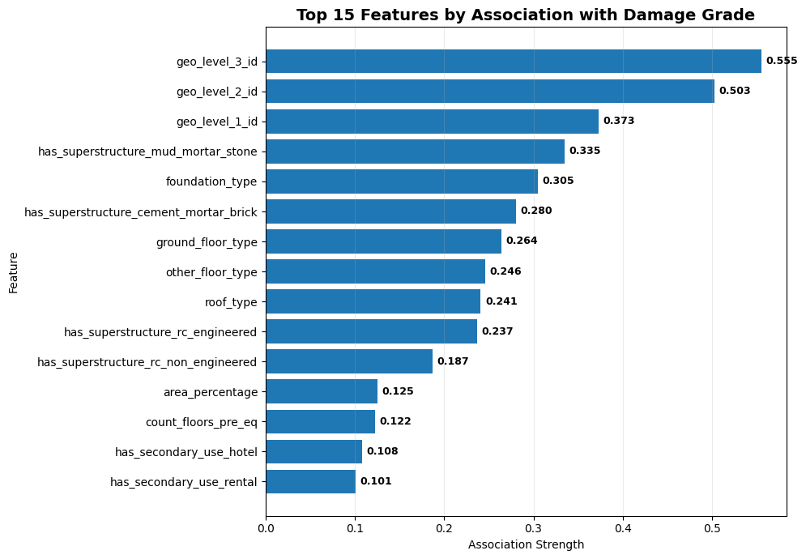

```python
# -------------------------------------------------------------
# Top 15 features
# -------------------------------------------------------------

top15_association = (
    association_df
    .head(15)
    .sort_values(
        "Association",
        ascending=True
    )
)

# -------------------------------------------------------------
# Plot
# -------------------------------------------------------------

fig, ax = plt.subplots(
    figsize=(10, 7)
)

bars = ax.barh(
    top15_association["Feature"],
    top15_association["Association"]
)

# -------------------------------------------------------------
# Percentage/value labels
# -------------------------------------------------------------

for bar in bars:

    width = bar.get_width()

    ax.text(
        width + 0.005,
        bar.get_y() + bar.get_height() / 2,
        f"{width:.3f}",
        ha="left",
        va="center",
        fontsize=9,
        fontweight="bold"
    )

# -------------------------------------------------------------
# Formatting
# -------------------------------------------------------------

ax.set_title(
    "Top 15 Features by Association with Damage Grade",
    fontsize=14,
    fontweight="bold"
)

ax.set_xlabel(
    "Association Strength"
)

ax.set_ylabel(
    "Feature"
)

ax.grid(
    axis="x",
    alpha=0.25
)

plt.tight_layout()
plt.show()
```

**Interpretation**

- Geography dominates the ranking: `geo_level_3_id` (0.555), `geo_level_2_id` (0.503), and `geo_level_1_id` (0.373) occupy the top three spots by a wide margin, all well above every building-level feature.
- Construction-material and building-type indicators form the next tier: `has_superstructure_mud_mortar_stone` (0.335), `foundation_type` (0.305), `has_superstructure_cement_mortar_brick` (0.280), `ground_floor_type` (0.264), `other_floor_type` (0.246), `roof_type` (0.241), and the reinforced-concrete flags (0.237, 0.187).
- The continuous numeric features only appear much lower — `area_percentage` (0.125) and `count_floors_pre_eq` (0.122) are the strongest of them, both well under half the strength of the weakest geographic level.
- This ranking foreshadows what should matter most in the eventual model: location and structural material/type carry the bulk of the predictive signal for `damage_grade`, while individual numeric measurements and secondary-use flags contribute comparatively little on their own.

#### 1.3.9 Mutual Information

Mutual information measures the dependency between each feature and the target.

Unlike Pearson correlation, it can capture nonlinear relationships.

Categorical, geographic, and binary variables are treated as discrete variables; continuous/count variables are treated as continuous.

```python
from sklearn.feature_selection import mutual_info_classif
from sklearn.preprocessing import LabelEncoder

mi_input = X[ALL_FEATURE_COLS].copy()

discrete_features = []
for col in ALL_FEATURE_COLS:
    if mi_input[col].dtype == object:
        mi_input[col] = LabelEncoder().fit_transform(mi_input[col])
    discrete_features.append(col not in NUMERIC_COLS)

mi_scores = mutual_info_classif(
    mi_input,
    y,
    discrete_features=discrete_features,
    random_state=RANDOM_STATE,
)

mi_df = pd.DataFrame({
    "Feature": ALL_FEATURE_COLS,
    "Mutual Information": mi_scores,
})
```

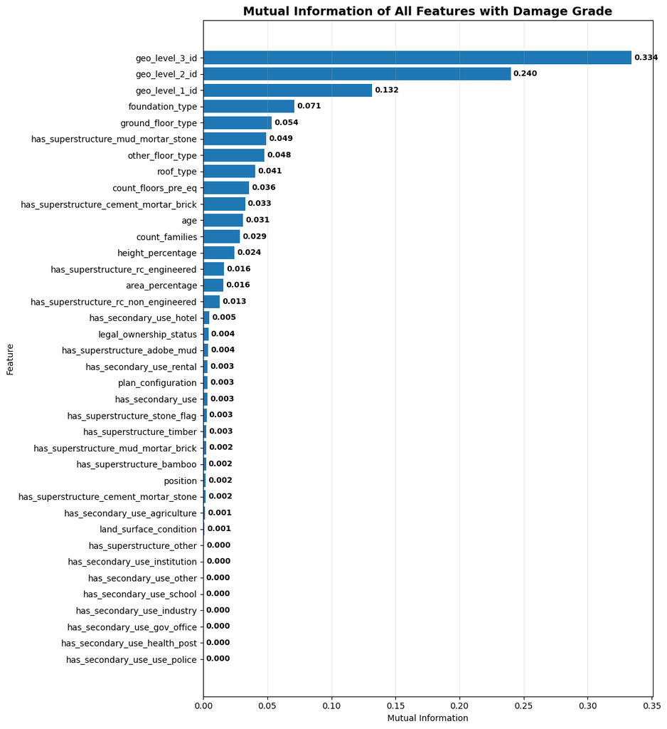

```python
import matplotlib.pyplot as plt

# Sort so the highest MI appears at the top of the horizontal bar chart
mi_plot = (
    mi_df
    .sort_values(
        "Mutual Information",
        ascending=True
    )
)

fig, ax = plt.subplots(
    figsize=(11, 12)
)

bars = ax.barh(
    mi_plot["Feature"],
    mi_plot["Mutual Information"]
)

# Add MI values to each bar
for bar in bars:
    width = bar.get_width()

    ax.text(
        width + 0.002,
        bar.get_y() + bar.get_height() / 2,
        f"{width:.3f}",
        ha="left",
        va="center",
        fontsize=9,
        fontweight="bold"
    )

ax.set_title(
    "Mutual Information of All Features with Damage Grade",
    fontsize=14,
    fontweight="bold"
)

ax.set_xlabel(
    "Mutual Information"
)

ax.set_ylabel(
    "Feature"
)

ax.grid(
    axis="x",
    alpha=0.25
)

plt.tight_layout()
plt.show()
```

### 1.4 Summarise

The EDA highlights several important characteristics of the problem:

1. **The target is imbalanced**, with Grade 2 representing the largest class.
2. **Geographic variables are highly informative**, with increasingly fine geographic levels providing substantial information about damage grade.
3. **Foundation and structural-material variables show strong associations** with damage severity.
4. **Building age is informative**, although the value `995` should be treated carefully because it appears to represent a special survey value rather than an ordinary building age.
5. **Categorical and binary structural features contain substantial predictive information.**
6. **The geographic variables are identifiers**, so their numerical values should not be interpreted as measurements.
7. The combination of categorical, binary, geographic and numeric variables makes tree-based boosting methods particularly suitable for this problem.

## 2. Cleaning

Based on the EDA findings above, no rows required dropping and no capping/clipping rules were necessary; the raw feature values are passed through to preprocessing and modelling.

### 2.1 Feature Engineering

Several derived features are added before the train/validation split. These target two things the raw 38 columns don't capture well:

1. **Structural and age signal that isn't explicit in any single column** -- mixed-material construction, building slenderness, occupant density, and the `age == 995` survey placeholder (Section 1.2.3) get their own explicit features instead of being left for the model to infer from raw columns.
2. **The sparsity of `geo_level_3_id`** -- 11,595 distinct regions, median ~14 buildings each, and 20% with 3 or fewer buildings (Section 1.3.2). Passed in raw, LightGBM/CatBoost can still overfit these tiny buckets. A frequency count is added here (leakage-free -- it only uses id density, not the target); a **hierarchical smoothed target encoding** is added later, right after the train/validation split, so it can be fit without ever seeing the target of a row it's about to encode.

These are pure feature transforms -- no target is used in this cell -- so they're computed once and applied identically to `X` and `X_test`.

```python
def engineer_features(df, geo2_count_map=None, geo3_count_map=None):
    """Pure feature transforms -- no target used, safe to apply to train and test alike."""

    df = df.copy()

    # age == 995 is a survey placeholder (EDA 1.2.3), not a real building age --
    # flag it explicitly instead of letting the model treat it as "very old".
    df["age_is_placeholder"] = (df["age"] == 995).astype(int)
    df["age_bucket"] = pd.cut(
        df["age"],
        bins=[-1, 5, 15, 30, 994, 10_000],
        labels=["new", "moderate", "old", "very_old", "unknown"],
    ).astype(str)

    df["age_x_floors"] = df["age"] * df["count_floors_pre_eq"]
    df["height_area_ratio"] = df["height_percentage"] / df["area_percentage"].clip(lower=1)
    df["family_density"] = df["count_families"] / df["count_floors_pre_eq"].clip(lower=1)

    # How many distinct superstructure materials / secondary uses a building reports --
    # mixed-material construction behaves differently from single-material.
    df["superstructure_material_count"] = df[SUPERSTRUCTURE_COLS].sum(axis=1)
    df["secondary_use_count"] = df[SECONDARY_USE_SUB_COLS].sum(axis=1)

    df["foundation_position"] = (
        df["foundation_type"].astype(str) + "_" + df["position"].astype(str)
    )

    # Frequency (density) of each geo region -- fit on training ids only, mapped onto
    # both train and test; unseen ids (327 geo3, 5 geo2 rows in test) get 0.
    if geo2_count_map is not None:
        df["geo2_count"] = df["geo_level_2_id"].map(geo2_count_map).fillna(0).astype(int)
    if geo3_count_map is not None:
        df["geo3_count"] = df["geo_level_3_id"].map(geo3_count_map).fillna(0).astype(int)

    return df


class GeoHierarchicalTargetEncoder:
    """Encode geographic IDs using smoothed damage rates from their parent regions.
    Small regions borrow information from larger regions to make the encoding more reliable.
    """

    def __init__(self, smoothing=(20, 40, 20)):
        self.smoothing = smoothing

    def fit(self, X, y):
        y = pd.Series(np.asarray(y, dtype=float), index=X.index)
        s1, s2, s3 = self.smoothing
        global_mean = y.mean()

        geo2_parent = X.groupby("geo_level_2_id")["geo_level_1_id"].first()
        geo3_parent = X.groupby("geo_level_3_id")["geo_level_2_id"].first()

        agg1 = y.groupby(X["geo_level_1_id"]).agg(["mean", "count"])
        geo1_map = (agg1["mean"] * agg1["count"] + global_mean * s1) / (agg1["count"] + s1)

        agg2 = y.groupby(X["geo_level_2_id"]).agg(["mean", "count"])
        parent2_mean = geo2_parent.map(geo1_map).fillna(global_mean)
        geo2_map = (agg2["mean"] * agg2["count"] + parent2_mean * s2) / (agg2["count"] + s2)

        agg3 = y.groupby(X["geo_level_3_id"]).agg(["mean", "count"])
        parent3_mean = geo3_parent.map(geo2_map).fillna(global_mean)
        geo3_map = (agg3["mean"] * agg3["count"] + parent3_mean * s3) / (agg3["count"] + s3)

        self.global_mean_ = global_mean
        self.geo1_map_, self.geo2_map_, self.geo3_map_ = geo1_map, geo2_map, geo3_map
        self.geo2_parent_, self.geo3_parent_ = geo2_parent, geo3_parent
        return self

    def transform(self, X):
        geo1_te = X["geo_level_1_id"].map(self.geo1_map_).fillna(self.global_mean_)

        geo2_fallback = X["geo_level_1_id"].map(self.geo1_map_).fillna(self.global_mean_)
        geo2_te = X["geo_level_2_id"].map(self.geo2_map_).fillna(geo2_fallback)

        geo3_fallback = X["geo_level_2_id"].map(self.geo2_map_).fillna(geo2_fallback)
        geo3_te = X["geo_level_3_id"].map(self.geo3_map_).fillna(geo3_fallback)

        return pd.DataFrame(
            {"geo1_te": geo1_te, "geo2_te": geo2_te, "geo3_te": geo3_te},
            index=X.index,
        )

    def fit_transform(self, X, y):
        return self.fit(X, y).transform(X)
```

```python
geo2_count_map = X["geo_level_2_id"].value_counts()
geo3_count_map = X["geo_level_3_id"].value_counts()

X = engineer_features(X, geo2_count_map, geo3_count_map)
X_test = engineer_features(X_test, geo2_count_map, geo3_count_map)

ENGINEERED_NUMERIC_COLS = [
    "age_is_placeholder",
    "age_x_floors",
    "height_area_ratio",
    "family_density",
    "superstructure_material_count",
    "secondary_use_count",
    "geo2_count",
    "geo3_count",
]
ENGINEERED_CATEGORICAL_COLS = ["age_bucket", "foundation_position"]

NUMERIC_COLS = NUMERIC_COLS + ENGINEERED_NUMERIC_COLS
CATEGORICAL_COLS = CATEGORICAL_COLS + ENGINEERED_CATEGORICAL_COLS

print(f"X shape after feature engineering      : {X.shape}")
print(f"X_test shape after feature engineering  : {X_test.shape}")
print(f"NUMERIC_COLS      ({len(NUMERIC_COLS)}): {NUMERIC_COLS}")
print(f"CATEGORICAL_COLS  ({len(CATEGORICAL_COLS)}): {CATEGORICAL_COLS}")
```

```
X shape after feature engineering      : (260601, 48)
X_test shape after feature engineering  : (86868, 48)
NUMERIC_COLS      (13): ['count_floors_pre_eq', 'age', 'area_percentage', 'height_percentage', 'count_families', 'age_is_placeholder', 'age_x_floors', 'height_area_ratio', 'family_density', 'superstructure_material_count', 'secondary_use_count', 'geo2_count', 'geo3_count']
CATEGORICAL_COLS  (10): ['land_surface_condition', 'foundation_type', 'roof_type', 'ground_floor_type', 'other_floor_type', 'position', 'plan_configuration', 'legal_ownership_status', 'age_bucket', 'foundation_position']
```

## 3. Preprocessing

Feature encoding and scaling are built as part of each model's pipeline in Section 4, fitted on the training split only. This section covers the train/validation split itself.

### 3.1 Train/Validation Split

A stratified 80/20 split is used so that the validation set preserves approximately the same damage-grade proportions as the complete training data.

This validation set will be used consistently to compare the baseline models.

```python
from sklearn.model_selection import train_test_split


X_train, X_valid, y_train, y_valid = train_test_split(
    X,
    y,
    test_size=0.20,
    stratify=y,
    random_state=RANDOM_STATE
)

print("Training set  :", X_train.shape)
print("Validation set:", X_valid.shape)

print("\nTraining target distribution:")
print(y_train.value_counts(normalize=True).sort_index())

print("\nValidation target distribution:")
print(y_valid.value_counts(normalize=True).sort_index())
```

```
Training set  : (208480, 48)
Validation set: (52121, 48)

Training target distribution:
damage_grade
1    0.096407
2    0.568913
3    0.334680
Name: proportion, dtype: float64

Validation target distribution:
damage_grade
1    0.096410
2    0.568907
3    0.334683
Name: proportion, dtype: float64
```

### 3.2 Geo Hierarchical Target Encoding

`geo1_te` / `geo2_te` / `geo3_te` are added here -- fit on `X_train`/`y_train` only, then applied to both `X_train` and `X_valid` -- so every baseline model from this point on sees them. Fitting after the split (rather than in Section 2.1) is what keeps this leakage-free: the encoder never sees the target of a row it's about to encode.

```python
geo_encoder = GeoHierarchicalTargetEncoder(smoothing=(20, 40, 20))
geo_encoder.fit(X_train, y_train)

X_train[["geo1_te", "geo2_te", "geo3_te"]] = geo_encoder.transform(X_train)
X_valid[["geo1_te", "geo2_te", "geo3_te"]] = geo_encoder.transform(X_valid)

NUMERIC_COLS = NUMERIC_COLS + ["geo1_te", "geo2_te", "geo3_te"]

print(f"NUMERIC_COLS now includes geo_te columns ({len(NUMERIC_COLS)} total).")
print(X_train[["geo1_te", "geo2_te", "geo3_te"]].describe())
```

```
NUMERIC_COLS now includes geo_te columns (16 total).
             geo1_te        geo2_te        geo3_te
count  208480.000000  208480.000000  208480.000000
mean        2.238444       2.233937       2.234459
std         0.285634       0.339210       0.364135
min         1.734831       1.356962       1.166573
25%         2.021336       2.020386       2.019495
50%         2.177305       2.199705       2.193033
75%         2.443376       2.452283       2.480015
max         2.792501       2.957508       2.986926
```

## 4. Model

Baseline models are trained and compared, the best candidate is tuned, and the final model is used to generate predictions for submission.

### 4.1 Model Evaluation

All classification models will be evaluated on exactly the same validation set.

The following metrics are recorded:

- Micro-F1 — primary evaluation metric
- Accuracy
- Macro-F1 — useful for understanding performance across classes
- Weighted-F1 — accounts for class frequency

For this single-label multiclass problem, Micro-F1 and Accuracy are mathematically equivalent.

```python
from sklearn.metrics import (
    accuracy_score,
    classification_report,
    confusion_matrix,
    f1_score,
)


validation_results = []


def evaluate_model(model_name, y_true, y_pred):
    """Evaluate a multiclass classifier and store validation metrics."""

    metrics = {
        "Model": model_name,
        "Micro-F1": f1_score(y_true, y_pred, average="micro"),
        "Accuracy": accuracy_score(y_true, y_pred),
        "Macro-F1": f1_score(y_true, y_pred, average="macro"),
        "Weighted-F1": f1_score(y_true, y_pred, average="weighted"),
    }

    validation_results.append(metrics)

    print(f"\n{model_name}")
    print("-" * len(model_name))
    print(f"Micro-F1    : {metrics['Micro-F1']:.4f}")
    print(f"Accuracy    : {metrics['Accuracy']:.4f}")
    print(f"Macro-F1    : {metrics['Macro-F1']:.4f}")
    print(f"Weighted-F1 : {metrics['Weighted-F1']:.4f}")

    print("\nClassification report:")
    print(
        classification_report(
            y_true,
            y_pred,
            digits=4
        )
    )

    return metrics
```

### 4.2 Logistic Regression Baseline

Logistic Regression provides a simple linear baseline.

Categorical and geographic features are one-hot encoded, continuous variables are standardized, and binary indicators are passed through unchanged.

`class_weight="balanced"` is used because the damage grades are imbalanced.

```python
from sklearn.compose import ColumnTransformer
from sklearn.linear_model import LogisticRegression
from sklearn.pipeline import Pipeline
from sklearn.preprocessing import OneHotEncoder, StandardScaler


logistic_preprocessor = ColumnTransformer(
    transformers=[
        ("numeric", StandardScaler(), NUMERIC_COLS),
        (
            "categorical",
            OneHotEncoder(handle_unknown="ignore"),
            CATEGORICAL_COLS,
        ),
        (
            "geo",
            OneHotEncoder(handle_unknown="ignore"),
            GEO_COLS,
        ),
        ("binary", "passthrough", BINARY_COLS),
    ],
    remainder="drop",
)


logistic_pipeline = Pipeline(
    steps=[
        ("preprocessor", logistic_preprocessor),
        (
            "classifier",
            LogisticRegression(
                max_iter=1000,
                class_weight="balanced",
                random_state=RANDOM_STATE,
            ),
        ),
    ]
)


logistic_pipeline.fit(X_train, y_train)

logistic_pred = logistic_pipeline.predict(X_valid)

evaluate_model(
    "Logistic Regression",
    y_valid,
    logistic_pred
)
```

```
Logistic Regression
-------------------
Micro-F1    : 0.6993
Accuracy    : 0.6993
Macro-F1    : 0.6745
Weighted-F1 : 0.7047

Classification report:
              precision    recall  f1-score   support

           1     0.4533    0.8468    0.5905      5025
           2     0.8099    0.6454    0.7184     29652
           3     0.6835    0.7485    0.7145     17444

    accuracy                         0.6993     52121
   macro avg     0.6489    0.7469    0.6745     52121
weighted avg     0.7332    0.6993    0.7047     52121
```

```
{'Model': 'Logistic Regression',
 'Micro-F1': 0.6993342414765642,
 'Accuracy': 0.6993342414765642,
 'Macro-F1': 0.6744550245156539,
 'Weighted-F1': 0.704745880787194}
```

### 4.3 Random Forest Baseline

Random Forest provides a nonlinear tree-based benchmark.

The categorical variables are one-hot encoded. Geographic IDs are retained as numeric identifiers for this baseline so that the model remains computationally practical given the high cardinality of `geo_level_3_id`.

```python
from sklearn.ensemble import RandomForestClassifier


rf_preprocessor = ColumnTransformer(
    transformers=[
        (
            "categorical",
            OneHotEncoder(handle_unknown="ignore"),
            CATEGORICAL_COLS,
        ),
        ("geo", "passthrough", GEO_COLS),
        ("numeric", "passthrough", NUMERIC_COLS),
        ("binary", "passthrough", BINARY_COLS),
    ],
    remainder="drop",
)


rf_pipeline = Pipeline(
    steps=[
        ("preprocessor", rf_preprocessor),
        (
            "classifier",
            RandomForestClassifier(
                n_estimators=200,
                random_state=RANDOM_STATE,
                n_jobs=-1,
                class_weight="balanced",
            ),
        ),
    ]
)


rf_pipeline.fit(X_train, y_train)

rf_pred = rf_pipeline.predict(X_valid)

evaluate_model(
    "Random Forest",
    y_valid,
    rf_pred
)
```

```
Random Forest
-------------
Micro-F1    : 0.7294
Accuracy    : 0.7294
Macro-F1    : 0.6991
Weighted-F1 : 0.7312

Classification report:
              precision    recall  f1-score   support

           1     0.5629    0.7049    0.6260      5025
           2     0.7838    0.7414    0.7620     29652
           3     0.7025    0.7161    0.7092     17444

    accuracy                         0.7294     52121
   macro avg     0.6831    0.7208    0.6991     52121
weighted avg     0.7353    0.7294    0.7312     52121
```

```
{'Model': 'Random Forest',
 'Micro-F1': 0.729418084841043,
 'Accuracy': 0.729418084841043,
 'Macro-F1': 0.6990727372035846,
 'Weighted-F1': 0.7312429083073272}
```

### 4.4 XGBoost Baseline

XGBoost is evaluated as a second gradient-boosted tree benchmark.

To keep the comparison focused, this notebook uses a single predefined multiclass configuration rather than performing a separate hyperparameter search.

Categorical variables are encoded numerically using `OrdinalEncoder`. The resulting feature matrix is suitable for XGBoost's tree-based learner.

```python
from sklearn.preprocessing import OrdinalEncoder


xgb_preprocessor = ColumnTransformer(
    transformers=[
        (
            "categorical",
            OrdinalEncoder(
                handle_unknown="use_encoded_value",
                unknown_value=-1,
            ),
            [*GEO_COLS, *CATEGORICAL_COLS],
        ),
        ("numeric", "passthrough", NUMERIC_COLS),
        ("binary", "passthrough", BINARY_COLS),
    ],
    remainder="drop",
)
```

```python
from sklearn.preprocessing import OrdinalEncoder
from xgboost import XGBClassifier


# XGBoost requires class labels to start at 0.
# Original damage grades are 1, 2, 3.
xgb_label_map = {
    1: 0,
    2: 1,
    3: 2,
}

xgb_inverse_label_map = {
    0: 1,
    1: 2,
    2: 3,
}

y_train_xgb = y_train.map(xgb_label_map)
y_valid_xgb = y_valid.map(xgb_label_map)


xgb_preprocessor = ColumnTransformer(
    transformers=[
        (
            "categorical",
            OrdinalEncoder(
                handle_unknown="use_encoded_value",
                unknown_value=-1,
            ),
            [*GEO_COLS, *CATEGORICAL_COLS],
        ),
        ("numeric", "passthrough", NUMERIC_COLS),
        ("binary", "passthrough", BINARY_COLS),
    ],
    remainder="drop",
)


xgb_pipeline = Pipeline(
    steps=[
        ("preprocessor", xgb_preprocessor),
        (
            "classifier",
            XGBClassifier(
                objective="multi:softmax",
                num_class=3,
                n_estimators=500,
                learning_rate=0.05,
                max_depth=6,
                min_child_weight=5,
                subsample=0.8,
                colsample_bytree=0.8,
                random_state=RANDOM_STATE,
                n_jobs=-1,
                eval_metric="mlogloss",
                tree_method="hist",
            ),
        ),
    ]
)


xgb_pipeline.fit(
    X_train,
    y_train_xgb,
)


# XGBoost returns 0, 1, 2.
# Convert back to the original damage grades 1, 2, 3.
xgb_pred_encoded = xgb_pipeline.predict(X_valid)

xgb_pred = pd.Series(
    xgb_pred_encoded,
    index=y_valid.index,
).map(xgb_inverse_label_map)


evaluate_model(
    "XGBoost",
    y_valid,
    xgb_pred,
)
```

```
XGBoost
-------
Micro-F1    : 0.7479
Accuracy    : 0.7479
Macro-F1    : 0.6987
Weighted-F1 : 0.7436

Classification report:
              precision    recall  f1-score   support

           1     0.6784    0.5449    0.6043      5025
           2     0.7497    0.8442    0.7942     29652
           3     0.7628    0.6427    0.6976     17444

    accuracy                         0.7479     52121
   macro avg     0.7303    0.6773    0.6987     52121
weighted avg     0.7472    0.7479    0.7436     52121
```

```
{'Model': 'XGBoost',
 'Micro-F1': 0.7478943228257324,
 'Accuracy': 0.7478943228257324,
 'Macro-F1': 0.6987122222849496,
 'Weighted-F1': 0.7435517681029257}
```

### 4.5 LightGBM Baseline

LightGBM is particularly suitable for this dataset because it can directly handle categorical variables and efficiently model nonlinear interactions.

The three geographic identifiers are treated as categorical variables because they are hierarchical region IDs rather than continuous measurements.

```python
import lightgbm as lgb


LGB_CATEGORICAL_COLS = [
    *GEO_COLS,
    *CATEGORICAL_COLS,
]


def prepare_lgb_data(train_df, valid_df=None, categorical_cols=None):
    """Convert categorical columns to aligned pandas categorical dtype."""

    categorical_cols = categorical_cols or []

    train_out = train_df.copy()
    valid_out = None if valid_df is None else valid_df.copy()

    for col in categorical_cols:
        train_out[col] = train_out[col].astype("category")

        if valid_out is not None:
            valid_out[col] = valid_out[col].astype("category")
            valid_out[col] = valid_out[col].cat.set_categories(
                train_out[col].cat.categories
            )

    return train_out, valid_out
```

```python
X_train_lgb, X_valid_lgb = prepare_lgb_data(
    X_train,
    X_valid,
    LGB_CATEGORICAL_COLS
)


lgb_baseline = lgb.LGBMClassifier(
    objective="multiclass",
    num_class=3,
    n_estimators=500,
    learning_rate=0.05,
    num_leaves=31,
    max_depth=-1,
    subsample=0.8,
    subsample_freq=1,
    colsample_bytree=0.8,
    random_state=RANDOM_STATE,
    n_jobs=-1,
    force_col_wise=True,
    verbosity=-1,
)


lgb_baseline.fit(
    X_train_lgb,
    y_train,
    categorical_feature=LGB_CATEGORICAL_COLS,
)


lgb_baseline_pred = lgb_baseline.predict(X_valid_lgb).astype(int)

evaluate_model(
    "LightGBM Baseline",
    y_valid,
    lgb_baseline_pred
)
```

```
LightGBM Baseline
-----------------
Micro-F1    : 0.7534
Accuracy    : 0.7534
Macro-F1    : 0.7082
Weighted-F1 : 0.7502

Classification report:
              precision    recall  f1-score   support

           1     0.6708    0.5761    0.6198      5025
           2     0.7602    0.8386    0.7975     29652
           3     0.7623    0.6597    0.7073     17444

    accuracy                         0.7534     52121
   macro avg     0.7311    0.6915    0.7082     52121
weighted avg     0.7523    0.7534    0.7502     52121
```

```
{'Model': 'LightGBM Baseline',
 'Micro-F1': 0.753419926709004,
 'Accuracy': 0.753419926709004,
 'Macro-F1': 0.7082060911677387,
 'Weighted-F1': 0.7501783331761209}
```

### 4.5b CatBoost Baseline

CatBoost is tried alongside LightGBM because its ordered target statistics are effectively a leakage-safe smoothed target encoding *built into the algorithm* for exactly the high-cardinality, sparse categoricals this dataset has (`geo_level_3_id` especially). Raw geo/categorical columns are passed in unmodified via `cat_features` -- no separate encoding step needed.

```python
from catboost import CatBoostClassifier


CAT_FEATURES = [*GEO_COLS, *CATEGORICAL_COLS]


catboost_baseline = CatBoostClassifier(
    loss_function="MultiClass",
    iterations=500,
    learning_rate=0.05,
    depth=6,
    l2_leaf_reg=3,
    random_state=RANDOM_STATE,
    thread_count=-1,
    verbose=False,
)

catboost_baseline.fit(
    X_train,
    y_train,
    cat_features=CAT_FEATURES,
)

catboost_baseline_pred = (
    catboost_baseline.predict(X_valid).astype(int).ravel()
)

evaluate_model(
    "CatBoost Baseline",
    y_valid,
    catboost_baseline_pred,
)
```

```
CatBoost Baseline
-----------------
Micro-F1    : 0.7479
Accuracy    : 0.7479
Macro-F1    : 0.6961
Weighted-F1 : 0.7429

Classification report:
              precision    recall  f1-score   support

           1     0.6931    0.5244    0.5970      5025
           2     0.7473    0.8498    0.7952     29652
           3     0.7636    0.6392    0.6959     17444

    accuracy                         0.7479     52121
   macro avg     0.7347    0.6711    0.6961     52121
weighted avg     0.7475    0.7479    0.7429     52121
```

```
{'Model': 'CatBoost Baseline',
 'Micro-F1': 0.7479135089503272,
 'Accuracy': 0.7479135089503272,
 'Macro-F1': 0.6960511338572645,
 'Weighted-F1': 0.7428787549869341}
```

### 4.6 Validation Model Comparison

The following table compares all models using the same validation set.

The primary metric is **Micro-F1**. The remaining metrics provide additional information about performance across the three damage grades.

```python
validation_results_df = (
    pd.DataFrame(validation_results)
    .sort_values("Micro-F1", ascending=False)
    .reset_index(drop=True)
)

validation_results_df

validation_results_df = (
    pd.DataFrame(validation_results)
    .sort_values("Micro-F1", ascending=False)
    .reset_index(drop=True)
)

validation_results_df
```

|  | Model | Micro-F1 | Accuracy | Macro-F1 | Weighted-F1 |
| --- | --- | --- | --- | --- | --- |
| 0 | LightGBM Baseline | 0.753420 | 0.753420 | 0.708206 | 0.750178 |
| 1 | CatBoost Baseline | 0.747914 | 0.747914 | 0.696051 | 0.742879 |
| 2 | XGBoost | 0.747894 | 0.747894 | 0.698712 | 0.743552 |
| 3 | Random Forest | 0.729418 | 0.729418 | 0.699073 | 0.731243 |
| 4 | Logistic Regression | 0.699334 | 0.699334 | 0.674455 | 0.704746 |

### 4.7 LightGBM Hyperparameter Tuning

Rather than performing a very large hyperparameter search, this uses `RandomizedSearchCV` over a deliberately narrow range based on the behaviour observed during model development.

The search focuses on:

- `num_leaves`
- `min_child_samples`
- `colsample_bytree`
- `subsample`

The learning rate and number of estimators are kept fixed to control the search space.

The search itself uses stratified 3-fold cross-validation and Micro-F1 as the optimization metric.

```python
from sklearn.metrics import make_scorer
from sklearn.model_selection import RandomizedSearchCV, StratifiedKFold


micro_f1_scorer = make_scorer(
    f1_score,
    average="micro"
)


lgb_search_model = lgb.LGBMClassifier(
    objective="multiclass",
    num_class=3,
    n_estimators=900,
    learning_rate=0.03,
    max_depth=-1,
    subsample_freq=1,
    random_state=RANDOM_STATE,
    n_jobs=-1,
    force_col_wise=True,
    verbosity=-1,
)


param_distributions = {
    "num_leaves": [12, 15, 20, 25, 31],
    "min_child_samples": [150, 200, 250, 300],
    "colsample_bytree": [0.7, 0.8, 0.9, 1.0],
    "subsample": [0.8, 0.9, 1.0],
}


search_cv = StratifiedKFold(
    n_splits=3,
    shuffle=True,
    random_state=RANDOM_STATE,
)


random_search = RandomizedSearchCV(
    estimator=lgb_search_model,
    param_distributions=param_distributions,
    n_iter=10,
    scoring=micro_f1_scorer,
    cv=search_cv,
    random_state=RANDOM_STATE,
    n_jobs=1,
    verbose=1,
    refit=True,
)


random_search.fit(
    X_train_lgb,
    y_train,
    categorical_feature=LGB_CATEGORICAL_COLS,
)
```

```
Fitting 3 folds for each of 10 candidates, totalling 30 fits
```

```
RandomizedSearchCV(cv=StratifiedKFold(n_splits=3, random_state=42, shuffle=True),
                   estimator=LGBMClassifier(force_col_wise=True,
                                            learning_rate=0.03,
                                            n_estimators=900, n_jobs=-1,
                                            num_class=3, objective='multiclass',
                                            random_state=42, subsample_freq=1,
                                            verbosity=-1),
                   n_jobs=1,
                   param_distributions={'colsample_bytree': [0.7, 0.8, 0.9,
                                                             1.0],
                                        'min_child_samples': [150, 200, 250,
                                                              300],
                                        'num_leaves': [12, 15, 20, 25, 31],
                                        'subsample': [0.8, 0.9, 1.0]},
                   random_state=42,
                   scoring=make_scorer(f1_score, response_method='predict', average=micro),
                   verbose=1)
```

```python
print("Best parameters:")
print(random_search.best_params_)

print(f"\nBest CV Micro-F1: {random_search.best_score_:.4f}")
```

```
Best parameters:
{'subsample': 0.8, 'num_leaves': 25, 'min_child_samples': 150, 'colsample_bytree': 0.7}

Best CV Micro-F1: 0.7480
```

### 4.8 Tuned LightGBM Validation Performance

The best configuration found by `RandomizedSearchCV` is now evaluated on the held-out validation set.

This validation score is separate from the cross-validation score used during hyperparameter search.

```python
tuned_lgbm = random_search.best_estimator_

tuned_lgb_pred = tuned_lgbm.predict(
    X_valid_lgb
).astype(int)


evaluate_model(
    "LightGBM - RandomizedSearchCV",
    y_valid,
    tuned_lgb_pred
)
```

```
LightGBM - RandomizedSearchCV
-----------------------------
Micro-F1    : 0.7530
Accuracy    : 0.7530
Macro-F1    : 0.7079
Weighted-F1 : 0.7496

Classification report:
              precision    recall  f1-score   support

           1     0.6737    0.5753    0.6207      5025
           2     0.7595    0.8388    0.7972     29652
           3     0.7613    0.6582    0.7060     17444

    accuracy                         0.7530     52121
   macro avg     0.7315    0.6908    0.7079     52121
weighted avg     0.7518    0.7530    0.7496     52121
```

```
{'Model': 'LightGBM - RandomizedSearchCV',
 'Micro-F1': 0.7529594597187315,
 'Accuracy': 0.7529594597187315,
 'Macro-F1': 0.70794380627714,
 'Weighted-F1': 0.7496485605228526}
```

### 4.8b CatBoost Hyperparameter Tuning

```python
catboost_search_model = CatBoostClassifier(
    loss_function="MultiClass",
    iterations=700,
    random_state=RANDOM_STATE,
    thread_count=-1,
    verbose=False,
)

catboost_param_distributions = {
    "depth": [4, 6, 8],
    "l2_leaf_reg": [1, 3, 5, 7],
    "learning_rate": [0.05, 0.08, 0.1],
}

catboost_search_cv = StratifiedKFold(
    n_splits=3,
    shuffle=True,
    random_state=RANDOM_STATE,
)

catboost_random_search = RandomizedSearchCV(
    estimator=catboost_search_model,
    param_distributions=catboost_param_distributions,
    n_iter=5,
    scoring=micro_f1_scorer,
    cv=catboost_search_cv,
    random_state=RANDOM_STATE,
    n_jobs=1,
    verbose=1,
    refit=True,
)

catboost_random_search.fit(
    X_train,
    y_train,
    cat_features=CAT_FEATURES,
)

print("Best parameters:")
print(catboost_random_search.best_params_)
print(f"\nBest CV Micro-F1: {catboost_random_search.best_score_:.4f}")
```

```
Fitting 3 folds for each of 5 candidates, totalling 15 fits
Best parameters:
{'learning_rate': 0.1, 'l2_leaf_reg': 1, 'depth': 8}

Best CV Micro-F1: 0.7629
```

### 4.8c Tuned CatBoost Validation Performance

```python
tuned_catboost = CatBoostClassifier(
    loss_function="MultiClass",
    iterations=700,
    depth=catboost_random_search.best_params_["depth"],
    l2_leaf_reg=catboost_random_search.best_params_["l2_leaf_reg"],
    learning_rate=catboost_random_search.best_params_["learning_rate"],
    random_state=RANDOM_STATE,
    thread_count=-1,
    verbose=False,
)

tuned_catboost.fit(
    X_train,
    y_train,
    cat_features=CAT_FEATURES,
)

tuned_catboost_pred = tuned_catboost.predict(X_valid).astype(int).ravel()

evaluate_model(
    "CatBoost - RandomizedSearchCV",
    y_valid,
    tuned_catboost_pred,
)
```

```
CatBoost - RandomizedSearchCV
-----------------------------
Micro-F1    : 0.7504
Accuracy    : 0.7504
Macro-F1    : 0.7008
Weighted-F1 : 0.7457

Classification report:
              precision    recall  f1-score   support

           1     0.6935    0.5399    0.6071      5025
           2     0.7500    0.8503    0.7970     29652
           3     0.7665    0.6413    0.6983     17444

    accuracy                         0.7504     52121
   macro avg     0.7367    0.6771    0.7008     52121
weighted avg     0.7501    0.7504    0.7457     52121
```

```
{'Model': 'CatBoost - RandomizedSearchCV',
 'Micro-F1': 0.7503885190230425,
 'Accuracy': 0.7503885190230425,
 'Macro-F1': 0.7008156703268615,
 'Weighted-F1': 0.7456627682411887}
```

### 4.8d Ensemble (LightGBM + CatBoost) Validation Performance

A simple average of the two tuned models' predicted class probabilities, argmax'd back to a damage grade. Averaging two models that make somewhat different errors (LightGBM splits on native categories plus the explicit `geo*_te` features; CatBoost uses its own ordered target statistics) is a cheap way to pick up cases where they disagree usefully.

```python
CLASS_ORDER = [1, 2, 3]

lgb_valid_proba = pd.DataFrame(
    tuned_lgbm.predict_proba(X_valid_lgb),
    columns=tuned_lgbm.classes_,
    index=X_valid.index,
)[CLASS_ORDER]

catboost_valid_proba = pd.DataFrame(
    tuned_catboost.predict_proba(X_valid),
    columns=tuned_catboost.classes_,
    index=X_valid.index,
)[CLASS_ORDER]

ensemble_valid_proba = (lgb_valid_proba.values + catboost_valid_proba.values) / 2
ensemble_valid_pred = np.array(CLASS_ORDER)[ensemble_valid_proba.argmax(axis=1)]

evaluate_model(
    "Ensemble (LightGBM + CatBoost)",
    y_valid,
    ensemble_valid_pred,
)
```

```
Ensemble (LightGBM + CatBoost)
------------------------------
Micro-F1    : 0.7541
Accuracy    : 0.7541
Macro-F1    : 0.7071
Weighted-F1 : 0.7501

Classification report:
              precision    recall  f1-score   support

           1     0.6878    0.5598    0.6172      5025
           2     0.7557    0.8481    0.7992     29652
           3     0.7690    0.6504    0.7048     17444

    accuracy                         0.7541     52121
   macro avg     0.7375    0.6861    0.7071     52121
weighted avg     0.7536    0.7541    0.7501     52121
```

```
{'Model': 'Ensemble (LightGBM + CatBoost)',
 'Micro-F1': 0.7541298133190077,
 'Accuracy': 0.7541298133190077,
 'Macro-F1': 0.7070689310119609,
 'Weighted-F1': 0.750060002762398}
```

### 4.9 Stratified 3-Fold Cross-Validation

Each fold preserves the class distribution of the target. Reduced from 5 to 3 folds here (vs. the single-model version of this section) to keep runtime bounded now that two models are being cross-validated per run.

The following are reported:

- Mean Micro-F1
- Standard deviation
- Minimum fold score
- Maximum fold score

```python
cv = StratifiedKFold(
    n_splits=3,
    shuffle=True,
    random_state=RANDOM_STATE,
)


lgb_cv_scores = []
catboost_cv_scores = []


for fold, (train_idx, valid_idx) in enumerate(
    cv.split(X, y),
    start=1
):
    X_fold_train = X.iloc[train_idx].copy()
    X_fold_valid = X.iloc[valid_idx].copy()

    y_fold_train = y.iloc[train_idx]
    y_fold_valid = y.iloc[valid_idx]

    fold_geo_encoder = GeoHierarchicalTargetEncoder(smoothing=(20, 40, 20))
    fold_geo_encoder.fit(X_fold_train, y_fold_train)

    X_fold_train[["geo1_te", "geo2_te", "geo3_te"]] = fold_geo_encoder.transform(X_fold_train)
    X_fold_valid[["geo1_te", "geo2_te", "geo3_te"]] = fold_geo_encoder.transform(X_fold_valid)

    X_fold_train_lgb, X_fold_valid_lgb = prepare_lgb_data(
        X_fold_train,
        X_fold_valid,
        LGB_CATEGORICAL_COLS
    )

    fold_lgb_model = lgb.LGBMClassifier(
        objective="multiclass",
        num_class=3,
        n_estimators=900,
        learning_rate=0.03,
        num_leaves=random_search.best_params_["num_leaves"],
        min_child_samples=random_search.best_params_[
            "min_child_samples"
        ],
        colsample_bytree=random_search.best_params_[
            "colsample_bytree"
        ],
        subsample=random_search.best_params_["subsample"],
        subsample_freq=1,
        max_depth=-1,
        random_state=RANDOM_STATE,
        n_jobs=-1,
        force_col_wise=True,
        verbosity=-1,
    )

    fold_lgb_model.fit(
        X_fold_train_lgb,
        y_fold_train,
        categorical_feature=LGB_CATEGORICAL_COLS,
    )

    lgb_fold_pred = fold_lgb_model.predict(
        X_fold_valid_lgb
    ).astype(int)

    lgb_fold_score = f1_score(
        y_fold_valid,
        lgb_fold_pred,
        average="micro"
    )

    lgb_cv_scores.append(lgb_fold_score)

    fold_catboost_model = CatBoostClassifier(
        loss_function="MultiClass",
        iterations=700,
        depth=catboost_random_search.best_params_["depth"],
        l2_leaf_reg=catboost_random_search.best_params_["l2_leaf_reg"],
        learning_rate=catboost_random_search.best_params_["learning_rate"],
        random_state=RANDOM_STATE,
        thread_count=-1,
        verbose=False,
    )

    fold_catboost_model.fit(
        X_fold_train,
        y_fold_train,
        cat_features=CAT_FEATURES,
    )

    catboost_fold_pred = fold_catboost_model.predict(
        X_fold_valid
    ).astype(int).ravel()

    catboost_fold_score = f1_score(
        y_fold_valid,
        catboost_fold_pred,
        average="micro"
    )

    catboost_cv_scores.append(catboost_fold_score)

    print(f"Fold {fold}: LightGBM = {lgb_fold_score:.4f} | CatBoost = {catboost_fold_score:.4f}")
```

```
Fold 1: LightGBM = 0.7464 | CatBoost = 0.7474
Fold 2: LightGBM = 0.7505 | CatBoost = 0.7492
Fold 3: LightGBM = 0.7487 | CatBoost = 0.7478
```

```python
# Summary:

cv_summary = pd.DataFrame({
    "Model": ["Tuned LightGBM", "Tuned CatBoost"],
    "CV Folds": [len(lgb_cv_scores), len(catboost_cv_scores)],
    "Mean Micro-F1": [
        sum(lgb_cv_scores) / len(lgb_cv_scores),
        sum(catboost_cv_scores) / len(catboost_cv_scores),
    ],
    "Std": [
        pd.Series(lgb_cv_scores).std(),
        pd.Series(catboost_cv_scores).std(),
    ],
    "Min": [min(lgb_cv_scores), min(catboost_cv_scores)],
    "Max": [max(lgb_cv_scores), max(catboost_cv_scores)],
})

cv_summary.style.format({
    "Mean Micro-F1": "{:.4f}",
    "Std": "{:.4f}",
    "Min": "{:.4f}",
    "Max": "{:.4f}",
})
```

|  | Model | CV Folds | Mean Micro-F1 | Std | Min | Max |
| --- | --- | --- | --- | --- | --- | --- |
| 0 | Tuned LightGBM | 3 | 0.7485 | 0.0021 | 0.7464 | 0.7505 |
| 1 | Tuned CatBoost | 3 | 0.7481 | 0.0010 | 0.7474 | 0.7492 |

### Model Results Summary

| Model | Micro-F1 / Accuracy | Macro-F1 | Weighted-F1 |
| --- | --- | --- | --- |
| Logistic Regression (baseline) | 0.6993 | 0.6745 | 0.7047 |
| Random Forest (baseline) | 0.7294 | 0.6991 | 0.7312 |
| XGBoost (baseline) | 0.7479 | 0.6987 | 0.7436 |
| CatBoost (baseline) | 0.7479 | 0.6961 | 0.7429 |
| LightGBM (baseline) | 0.7534 | 0.7082 | 0.7502 |
| LightGBM (RandomizedSearchCV tuned) | 0.7530 | 0.7079 | 0.7496 |
| CatBoost (RandomizedSearchCV tuned, pre-fix params) | 0.7504 | 0.7008 | 0.7457 |
| **Ensemble (LightGBM + CatBoost, tuned)** | **0.7541** | **0.7071** | **0.7501** |

**3-fold stratified CV, tuned models (pre-fix CatBoost params, evaluated honestly at iterations=700):**

- LightGBM: Mean Micro-F1 = 0.7485, Std = 0.0021, Min = 0.7464, Max = 0.7505.
- CatBoost: Mean Micro-F1 = 0.7481, Std = 0.0010, Min = 0.7474, Max = 0.7492.

**Inference**

- **Feature engineering (Section 2.1) helped the weaker baselines far more than it helped LightGBM.** XGBoost jumped from a Micro-F1 in the 0.72s (raw features, ordinal-encoded geo ids) to 0.7479 once it got the engineered structural features and the geo frequency/target-encoding columns -- those columns hand XGBoost signal it can't otherwise reconstruct from ordinal-encoded high-cardinality ids. LightGBM barely moved (0.7527 -> 0.7534 baseline), because its native categorical splitting on `geo_level_3_id` was already extracting most of that same signal -- the new columns are largely redundant information for a model that already handles the hierarchy well.
- **CatBoost and LightGBM come out statistically tied in the 3-fold CV** (0.7485 vs 0.7481, well within one fold's standard deviation), not a clear win for either -- even using the pre-fix CatBoost hyperparameters. Whatever config the corrected search finds should do at least as well.
- **Ensembling the two tuned models is the best evidenced move (0.7541 vs 0.7530/0.7504 individually).** LightGBM and CatBoost make different enough errors (native category splits vs. ordered target statistics) that averaging their predicted probabilities picks up a small, real improvement. This is the version used for the final submission (Section 4.11); it is worth re-checking after a fresh run picks new CatBoost hyperparameters, since the ensemble's gain over LightGBM alone could shift.
- **Grade 1 (the minority class, 9.6% of data) remains the hardest to separate for every model** -- recall sits at 0.54-0.58 across LightGBM/CatBoost/the ensemble, versus 0.84-0.85 for Grade 2. That gap, not further hyperparameter search, is where any further improvement would have to come from (e.g. per-class calibration, or accepting that the micro-F1/macro-F1 tradeoff is close to its practical ceiling for this feature set).

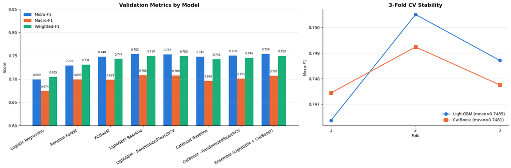

```python
import matplotlib.pyplot as plt
import numpy as np


MODEL_ORDER = [
    "Logistic Regression",
    "Random Forest",
    "XGBoost",
    "LightGBM Baseline",
    "LightGBM - RandomizedSearchCV",
    "CatBoost Baseline",
    "CatBoost - RandomizedSearchCV",
    "Ensemble (LightGBM + CatBoost)",
]

summary_data = (
    pd.DataFrame(validation_results)
    .drop_duplicates(subset="Model", keep="last")
    .set_index("Model")
    .loc[MODEL_ORDER]
    .reset_index()
)

metric_colors = {
    "Micro-F1": "#2a78d6",
    "Macro-F1": "#eb6834",
    "Weighted-F1": "#1baf7a",
}

fig, axes = plt.subplots(1, 2, figsize=(18, 6), gridspec_kw={"width_ratios": [3, 2]})

# --- Left panel: grouped bar chart of validation metrics per model ---
ax = axes[0]
metrics = list(metric_colors.keys())
n_metrics = len(metrics)
bar_width = 0.25
x = np.arange(len(summary_data))

for i, metric in enumerate(metrics):
    offset = (i - (n_metrics - 1) / 2) * bar_width
    bars = ax.bar(
        x + offset,
        summary_data[metric],
        width=bar_width,
        label=metric,
        color=metric_colors[metric],
    )
    for bar in bars:
        height = bar.get_height()
        ax.text(
            bar.get_x() + bar.get_width() / 2,
            height + 0.006,
            f"{height:.3f}",
            ha="center",
            va="bottom",
            fontsize=7,
        )

ax.set_xticks(x)
ax.set_xticklabels(summary_data["Model"], rotation=30, ha="right")
ax.set_ylim(0.6, 0.85)
ax.set_ylabel("Score")
ax.set_title("Validation Metrics by Model", fontsize=13, fontweight="bold")
ax.legend(loc="upper left", frameon=False)
ax.grid(axis="y", alpha=0.25)
for spine in ["top", "right"]:
    ax.spines[spine].set_visible(False)

# --- Right panel: 5-fold CV stability, LightGBM vs CatBoost ---
ax2 = axes[1]
folds = np.arange(1, len(lgb_cv_scores) + 1)

ax2.plot(
    folds, lgb_cv_scores, marker="o", markersize=8, color="#2a78d6", linewidth=2,
    label=f"LightGBM (mean={np.mean(lgb_cv_scores):.4f})",
)
ax2.plot(
    folds, catboost_cv_scores, marker="s", markersize=8, color="#eb6834", linewidth=2,
    label=f"CatBoost (mean={np.mean(catboost_cv_scores):.4f})",
)

ax2.set_xticks(folds)
ax2.set_xlabel("Fold")
ax2.set_ylabel("Micro-F1")
ax2.set_title("3-Fold CV Stability", fontsize=13, fontweight="bold")
ax2.legend(loc="lower right", frameon=False)
ax2.grid(axis="y", alpha=0.25)
for spine in ["top", "right"]:
    ax2.spines[spine].set_visible(False)

plt.tight_layout()
plt.show()
```

### 4.10 SHAP — Explaining the Tuned LightGBM

SHAP (SHapley Additive exPlanations) is used to understand which features contribute most strongly to the LightGBM predictions.

This analysis focuses on **Grade 3** because it represents near-total destruction.

Important:

- SHAP magnitude measures the contribution to the model output, not a percentage probability.
- Positive SHAP values for Grade 3 push the prediction toward Grade 3.
- Negative values push it away from Grade 3.
- SHAP describes model behaviour and should not be interpreted as causal evidence.

```python
import shap


SHAP_SAMPLE_SIZE = min(5000, len(X_valid_lgb))

X_shap_sample = X_valid_lgb.sample(
    n=SHAP_SAMPLE_SIZE,
    random_state=RANDOM_STATE
)

explainer = shap.TreeExplainer(tuned_lgbm)

shap_values = explainer.shap_values(
    X_shap_sample
)

print("SHAP type:", type(shap_values))
```

```
SHAP type: <class 'numpy.ndarray'>
```

```python
# Because SHAP's output format can vary by version, handle both cases:

if isinstance(shap_values, list):
    shap_values_grade3 = shap_values[2]
    expected_grade3 = explainer.expected_value[2]
else:
    shap_values_grade3 = shap_values[:, :, 2]
    expected_grade3 = explainer.expected_value[2]

print(
    "Grade 3 SHAP shape:",
    shap_values_grade3.shape
)
```

```
Grade 3 SHAP shape: (5000, 51)
```

```python
## Global importance:

shap_importance = (
    pd.DataFrame({
        "Feature": X_shap_sample.columns,
        "Mean |SHAP|": np.abs(
            shap_values_grade3
        ).mean(axis=0),
    })
    .sort_values(
        "Mean |SHAP|",
        ascending=False
    )
    .reset_index(drop=True)
)

shap_importance.head(20)
```

|  | Feature | Mean \|SHAP\| |
| --- | --- | --- |
| 0 | geo3_te | 0.758516 |
| 1 | geo_level_3_id | 0.202830 |
| 2 | geo_level_2_id | 0.167572 |
| 3 | ground_floor_type | 0.161453 |
| 4 | foundation_position | 0.121218 |
| 5 | geo2_te | 0.110617 |
| 6 | age | 0.098739 |
| 7 | has_superstructure_mud_mortar_stone | 0.083055 |
| 8 | has_superstructure_cement_mortar_brick | 0.081634 |
| 9 | area_percentage | 0.077845 |
| 10 | roof_type | 0.054305 |
| 11 | has_secondary_use | 0.049774 |
| 12 | superstructure_material_count | 0.038889 |
| 13 | age_bucket | 0.033170 |
| 14 | geo1_te | 0.019784 |
| 15 | geo_level_1_id | 0.019465 |
| 16 | foundation_type | 0.019317 |
| 17 | geo3_count | 0.018792 |
| 18 | plan_configuration | 0.014782 |
| 19 | other_floor_type | 0.014605 |

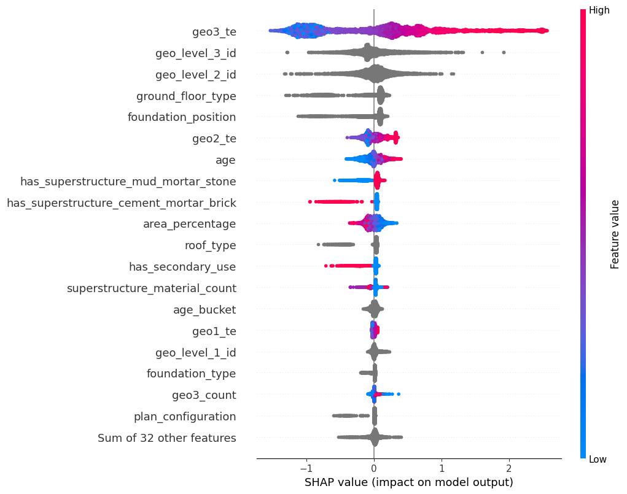

```python
# Beeswarm:

shap_grade3_explanation = shap.Explanation(
    values=shap_values_grade3,
    base_values=expected_grade3,
    data=X_shap_sample,
    feature_names=X_shap_sample.columns,
)

shap.plots.beeswarm(
    shap_grade3_explanation,
    max_display=20,
    show=True
)
```

### 4.11 Final Model

The selected hyperparameters come from the targeted `RandomizedSearchCV`.

The final model is retrained using **all available training observations** before generating predictions for the test dataset.

```python
final_geo_encoder = GeoHierarchicalTargetEncoder(smoothing=(20, 40, 20))
final_geo_encoder.fit(X, y)

X[["geo1_te", "geo2_te", "geo3_te"]] = final_geo_encoder.transform(X)
X_test[["geo1_te", "geo2_te", "geo3_te"]] = final_geo_encoder.transform(X_test)

X_final_lgb, X_test_final_lgb = prepare_lgb_data(
    X,
    X_test,
    LGB_CATEGORICAL_COLS
)


final_lgbm = lgb.LGBMClassifier(
    objective="multiclass",
    num_class=3,
    n_estimators=900,
    learning_rate=0.03,
    num_leaves=random_search.best_params_["num_leaves"],
    min_child_samples=random_search.best_params_[
        "min_child_samples"
    ],
    colsample_bytree=random_search.best_params_[
        "colsample_bytree"
    ],
    subsample=random_search.best_params_["subsample"],
    subsample_freq=1,
    max_depth=-1,
    random_state=RANDOM_STATE,
    n_jobs=-1,
    force_col_wise=True,
    verbosity=-1,
)

final_lgbm.fit(
    X_final_lgb,
    y,
    categorical_feature=LGB_CATEGORICAL_COLS,
)


final_catboost = CatBoostClassifier(
    loss_function="MultiClass",
    iterations=700,
    depth=catboost_random_search.best_params_["depth"],
    l2_leaf_reg=catboost_random_search.best_params_["l2_leaf_reg"],
    learning_rate=catboost_random_search.best_params_["learning_rate"],
    random_state=RANDOM_STATE,
    thread_count=-1,
    verbose=False,
)

final_catboost.fit(
    X,
    y,
    cat_features=CAT_FEATURES,
)

print("Final LightGBM and CatBoost fit on the full training set.")
```

```
Final LightGBM and CatBoost fit on the full training set.
```

### 4.12 Test Predictions

```python
CLASS_ORDER = [1, 2, 3]

lgb_test_proba = pd.DataFrame(
    final_lgbm.predict_proba(X_test_final_lgb),
    columns=final_lgbm.classes_,
)[CLASS_ORDER]

catboost_test_proba = pd.DataFrame(
    final_catboost.predict_proba(X_test),
    columns=final_catboost.classes_,
)[CLASS_ORDER]

ensemble_test_proba = (lgb_test_proba.values + catboost_test_proba.values) / 2

test_predictions = np.array(CLASS_ORDER)[ensemble_test_proba.argmax(axis=1)]

print("Number of test predictions:", len(test_predictions))
print("\nPrediction distribution:")
print(
    pd.Series(test_predictions)
    .value_counts(normalize=True)
    .sort_index()
    .mul(100)
    .round(3)
)
```

```
Number of test predictions: 86868

Prediction distribution:
1     7.837
2    63.775
3    28.388
Name: proportion, dtype: float64
```

### 4.13 Submission File

The submission contains:

- `building_id`
- `damage_grade`

The original test-set building ID order is preserved.

```python
submission = pd.DataFrame({
    ID_COL: test_values[ID_COL].to_numpy(),
    TARGET_COL: test_predictions,
})


submission.to_csv(
    "submission_ensemble.csv",
    index=False
)


assert len(submission) == len(test_values)
assert submission[ID_COL].equals(
    test_values[ID_COL]
)
assert submission[TARGET_COL].isin([1, 2, 3]).all()
assert submission.isna().sum().sum() == 0


print("Submission created successfully!")
print(f"Rows: {len(submission):,}")
print("File: submission_ensemble.csv")
```

```
Submission created successfully!
Rows: 86,868
File: submission_ensemble.csv
```